# Case Study: Reddit Social Network Analysis Against Influence Operation

Adel Abu Hashim, David Yacoup & Mahmoud Nagy - August 2021

[figure not shown]

>

- Introduction
- Data Wrangling
- Data Cleaning
- Exploratory Data Analysis
- Conclusions

## Introduction

> This case study aims to help **Amber Heard**

> By analyzing new accounts posting/ commenting against a victim of a Social Bot Disinformation/Influence Operation.

> **We have three main datasets**:  
> (The datasets screaped from **reddit**).
> - 1- A dataset with submissions & comments data (2020).
> - 2- Users Data (from 2006 to 2021)
> - 3- Daily creation data (# of accounts created per day from 2006 to 2021)

```python
# read main dataframe for year 2020 as reddit_20
parse_dates = ['created_at']
df = pd.read_csv("./reddit_2020.csv",lineterminator='\n', parse_dates=parse_dates)
print(df.shape)
df.head()
```

```
(128408, 15)
```

|  | _index | _type | _id | _score | id | name | permalink | text | parent_id | subreddit | author | created_at | entities.urls | sentiment_blob | sentiment_nltk |
| --- | --- | --- | --- | --- | --- | --- | --- | --- | --- | --- | --- | --- | --- | --- | --- |
| 0 | reddit | _doc | iVjxa3oBZsCJ_ScUg-Dh | 1.0 | ewweg2 | t3_ewweg2 | /r/MensRights/comments/ewweg2/amber_heard_admits_to_hitting_exhusband_johnny/ | Amber Heard admits to 'hitting' ex-husband Johnny Depp and pelting him with pots and pans on tape 'I can't promise I won't get physical again, I get so mad I lose it.' | NaN | r/MensRights | furchfur | 2020-01-31 22:45:00+00:00 | [] | Negative | Neutral |
| 1 | reddit | _doc | iljxa3oBZsCJ_ScUg-Dp | 1.0 | fg4yv0g | t1_fg4yv0g | /r/MensRights/comments/ewweg2/amber_heard_admits_to_hitting_exhusband_johnny/fg4yv0g/ | > I can't promise you I won't get physical again. God I f**king sometimes get so mad I lose it.'\n\nSo she's a danger to herself and others? | t3_ewweg2 | r/MensRights | MarsNirgal | 2020-01-31 23:43:32+00:00 | [] | Negative | Neutral |
| 2 | reddit | _doc | jFjxa3oBZsCJ_ScUg-D1 | 1.0 | fg4ut4q | t1_fg4ut4q | /r/MensRights/comments/ewweg2/amber_heard_admits_to_hitting_exhusband_johnny/fg4ut4q/ | it's a known fact that she was mentally unstable | t3_ewweg2 | r/MensRights | sleeping_shinigami | 2020-01-31 22:59:35+00:00 | [] | Negative | Negative |
| 3 | reddit | _doc | k1jxa3oBZsCJ_ScUhOAa | 1.0 | fg4zpdm | t1_fg4zpdm | /r/MensRights/comments/ewweg2/amber_heard_admits_to_hitting_exhusband_johnny/fg4zpdm/ | https://archive.fo/1z4NI | t3_ewweg2 | r/MensRights | NotherThrowaway284 | 2020-01-31 23:52:52+00:00 | [{'display_url': 'https://archive.fo'}] | Neutral | Neutral |
| 4 | reddit | _doc | pVjxa3oBZsCJ_ScUhOB6 | 1.0 | fg4zk3p | t1_fg4zk3p | /r/MensRights/comments/ewweg2/amber_heard_admits_to_hitting_exhusband_johnny/fg4zk3p/ | Yep. | t1_fg4yv0g | r/MensRights | NotherThrowaway284 | 2020-01-31 23:51:14+00:00 | [] | Neutral | Positive |

## Data Wrangling

- Introduction
- **Data Wrangling**
- Data Cleaning
- Exploratory Data Analysis
- Conclusions

### REDDIT_DF

> > | Column | Description |
> > | --- | --- |
> > | subreddit | a forum dedicated to a specific topic on the website Reddit. |
> > | parent_id | will be the thing directly preceding the comment. If it's a top level comment parent_id will describe a submission (t3), otherwise it will describe a comment (t1). and it is the parent of the comment.… |
> > | permalink | A permalink or permanent link is a URL that is intended to remain unchanged for many years into the future, yielding a hyperlink that is less susceptible to link rot. Permalinks are often rendered sim… |

### df_users

> > | Column | Description |
> > | --- | --- |
> > | author.name | unique name of the user |
> > | created_at | date and time of account creation |
> > | author.has_verified_email | the author verify his email |
> > | author.is_employee | the author is employee |
> > | author.is_mod | the author is room moderator |
> > | author.is_gold | Gold is a way to show appreciation for an exceptional contribution to Reddit. |

### df_daily_creation

> > | Column | Description |
> > | --- | --- |
> > | created_at -> (created_at) | date of user creation |
> > | author.name -> (n_accounts) | the number of creation accounts |

# Data Cleaning

- Introduction
- Data Wrangling
- **Data Cleaning**
- Exploratory Data Analysis
- Conclusions
- 2020 Data
- Users Data
- Daily Creation Data

```python
type(df_cleaned['created_at'][0])
```

```
pandas._libs.tslibs.timestamps.Timestamp
```

```python
df_users_cleaned.info()
```

```
<class 'pandas.core.frame.DataFrame'>
RangeIndex: 70573 entries, 0 to 70572
Data columns (total 7 columns):
 #   Column              Non-Null Count  Dtype
---  ------              --------------  -----
 0   name                70573 non-null  object
 1   created_at          65910 non-null  datetime64[ns, UTC]
 2   has_verified_email  65792 non-null  object
 3   is_employee         65910 non-null  object
 4   is_mod              65910 non-null  object
 5   is_gold             65910 non-null  object
 6   is_banned           70573 non-null  bool
dtypes: bool(1), datetime64[ns, UTC](1), object(5)
memory usage: 3.3+ MB
```

## Exploratory Data Analysis

- Introduction
- Data Wrangling
- Data Cleaning
- **Exploratory Data Analysis**
- Conclusions
- **Daily Creation Data**
- User Charcterstics
- Reddit Comments/Submissions Data
- Merged Users Data with Comments/Submissions Data

### Exploring Daily Creation Data

### Estimation of the number of user accounts created in each year

```python
fig = px.bar(df_daily_creation_cleaned.groupby('creation_year').sum('n_accounts').reset_index(),
             x='creation_year', y='n_accounts', text='n_accounts', title='Accounts Creation by years')
fig.update_traces(marker_color='#f69c56',
                  marker_line_width=1.5, opacity=1, textposition='auto')
fig.show()
```

[interactive chart not shown]

```python
df_daily_creation_cleaned['creation_month']  = df_daily_creation_cleaned['created_at'].dt.month
```

```python
creation_month_2019 = df_daily_creation_cleaned[df_daily_creation_cleaned['creation_year'] == 2019]
```

```python
fig = px.bar(creation_month_2019.groupby('creation_month').sum('n_accounts').reset_index(),
             x='creation_month', y='n_accounts', text='n_accounts', title='Accounts Creation in 2019')
fig.update_traces(marker_color='#f69c56',
                  marker_line_width=1.5, opacity=1, textposition='auto')
fig.show()
```

[interactive chart not shown]

- Daily Creation Data
- **User Charcterstics**
- Reddit Comments/Submissions Data
- Merged Users Data with Comments/Submissions Data

### User Charcterstics

> > Mod -> Moderator

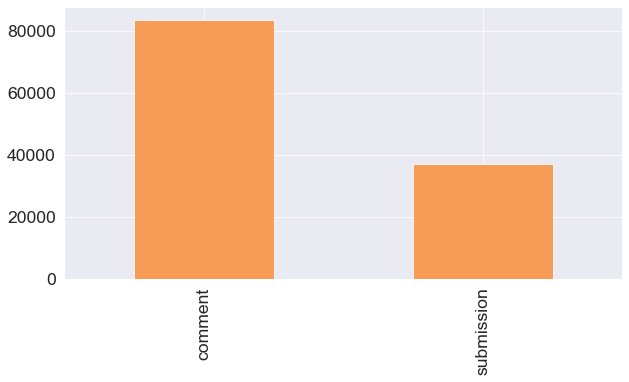

```python
df_cleaned['top_level'].value_counts().plot(kind='bar', color='#f69c56');
```

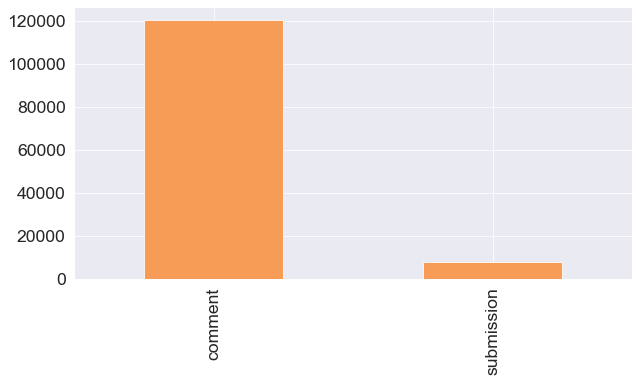

```python
df_cleaned['submission_comment'].value_counts().plot(kind='bar', color='#f69c56');
```

### NLTK vs BLOB clssification

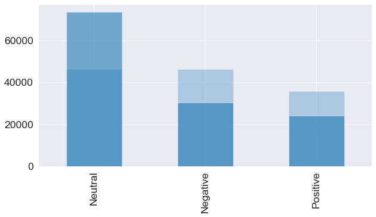

```python
df_cleaned.sentiment_blob.value_counts().plot(kind='bar', alpha = 0.3);
df_cleaned.sentiment_nltk.value_counts().plot(kind='bar', alpha = 0.6);
```

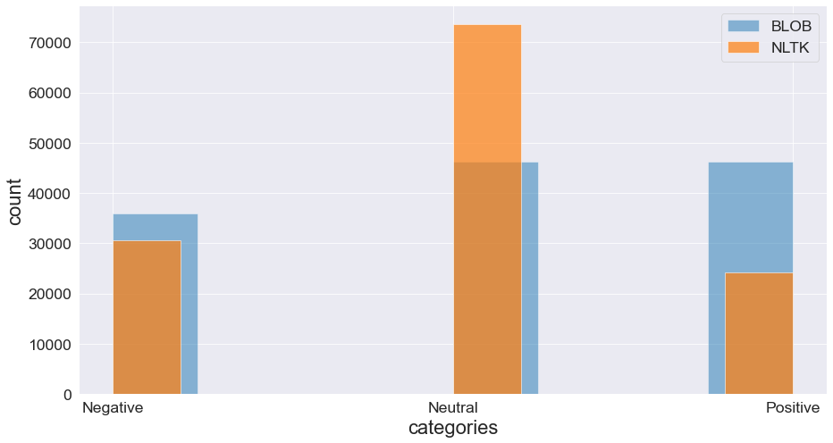

```python
fig , ax = plt.subplots(figsize = (15,8))
df_cleaned.sentiment_blob.hist(alpha = 0.5 , bins = 8 , label = 'BLOB')
df_cleaned.sentiment_nltk.hist(alpha = 0.7 , bins = 10 , label = 'NLTK')

plt.xlabel('categories');
plt.ylabel('count');
ax.legend();
```

```python
df_sentiment = pd.merge(df_cleaned.sentiment_nltk.value_counts().to_frame(),
        df_cleaned.sentiment_blob.value_counts().to_frame(),
        left_index=True, right_index=True)
print(df_sentiment)
```

```
          sentiment_nltk  sentiment_blob
Neutral            73578           46247
Negative           30545           35888
Positive           24285           46273
```

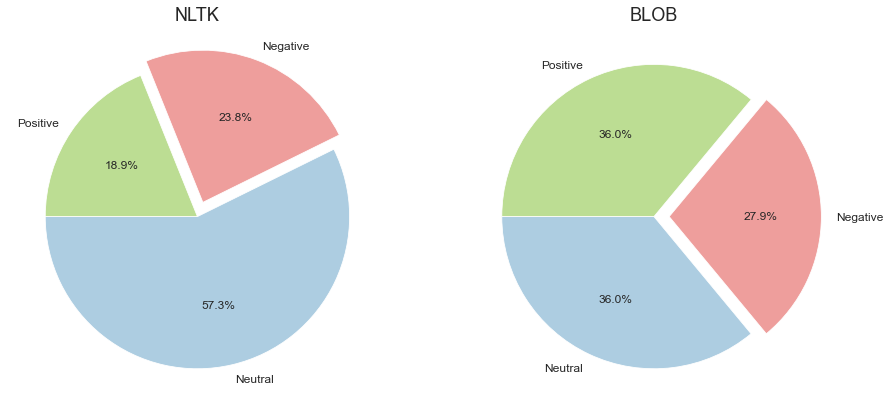

```python
explode = [0, 0.1, 0]

fig, (ax1, ax2) = plt.subplots(1, 2, figsize = (15,8))
ax1.pie(df_sentiment.sentiment_nltk,
        labels = df_sentiment.index,
        autopct='%1.1f%%',
        explode = explode,
        textprops={'fontsize': 12},
#         textprops={'color':"w"},
        colors = ['#adcde1', '#ee9e9c', '#bcdd93'],
        startangle=180)
ax2.pie(df_sentiment.sentiment_blob,
        labels = df_sentiment.index,
        colors =  ['#adcde1', '#ee9e9c', '#bcdd93'],
        autopct='%1.1f%%',
        explode = explode,
        textprops={'fontsize': 12},
        startangle=180)
ax1.set_title('NLTK', fontdict = {'fontsize' : 18})
ax2.set_title('BLOB', fontdict = {'fontsize' : 18})
plt.show()
```

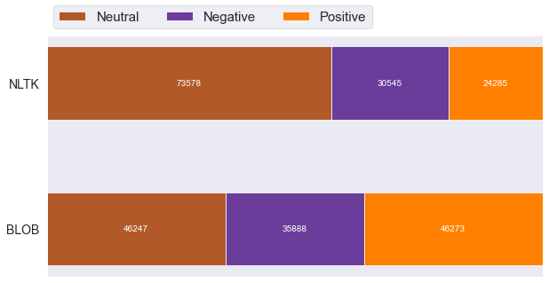

```python
category_names = df_sentiment.index
dict_models = {
    'NLTK': df_sentiment.sentiment_nltk,
    'BLOB': df_sentiment.sentiment_blob
}


def models(dict_models, category_names):

    labels = list(dict_models.keys())
    data = np.array(list(dict_models.values()))
    data_cum = data.cumsum(axis=1)
    category_colors = plt.get_cmap('Paired_r')(
        np.linspace(0.08, 0.40, data.shape[1]))

    fig, ax = plt.subplots(figsize=(10, 5))
    ax.invert_yaxis()
    ax.xaxis.set_visible(False)
    ax.set_xlim(0, np.sum(data, axis=1).max())

    for i, (colname, color) in enumerate(zip(category_names, category_colors)):
        widths = data[:, i]
        starts = data_cum[:, i] - widths
        ax.barh(labels, widths, left=starts, height=0.5,
                label=colname, color=color)
        xcenters = starts + widths / 2

        g, r, b, _ = color
        text_color = 'white' if g * r * b < 0.25 else 'black'
        for y, (x, c) in enumerate(zip(xcenters, widths)):
            ax.text(x, y, str(int(c)), ha='center', va='center',
                    color=text_color)
    ax.legend(ncol=len(category_names), bbox_to_anchor=(0, 1),
              loc='lower left', fontsize=15)
    ax.tick_params(labelsize=14)
    sns.set_context('paper', font_scale=2) # --> just scaling all of the font sizes

    return fig, ax


models(dict_models, category_names)
plt.show()
```

### Investigate the text column

```python
df_cleaned.text.value_counts().head(60)
```

```
[deleted]                                                                                                                                                                                                                                                                                                   …
[removed]                                                                                                                                                                                                                                                                                                   …
Amber Heard                                                                                                                                                                                                                                                                                                 …
Make sure to follow our community guidelines.\n\n**[Get user flair](https://redd.it/e0a4mn) and check out our [Instagram page](https://www.instagram.com/celebtag) for more celebrity content!**\n\n\n*I am a bot, and this action was performed automatically. Please [contact the moderators of this subre…
Rule 9 overused. No Johny Depp or Amber Heard memes at this time\n\n*I am a bot, and this action was performed automatically. Please [contact the moderators of this subreddit](/message/compose/?to=/r/memes) if you have any questions or concerns.*                                                      …
**PLEASE READ ALL OF THIS BEFORE MESSAGING US:**\n\nThank you for your submission, but it has been removed due to lack of context.  \n\n**Please see Rule 2** and repost with a **URL or a screenshot** (you can host it on imgur.com) **in your submission body** so that the users can better know what yo…
Amber                                                                                                                                                                                                                                                                                                       …
Yes                                                                                                                                                                                                                                                                                                         …
Amber Turd                                                                                                                                                                                                                                                                                                  …
Your opinion about celebrity relationships has been reposted dozens of times today. Please join a celebrity gossip sub. Thanks.\n\n*I am a bot, and this action was performed automatically. Please [contact the moderators of this subreddit](/message/compose/?to=/r/unpopularopinion) if you have any que…
http://chng.it/yV5kVspG9x\n\n#JusticeForJohnnyDepp \nPlease check out the articles and sign the petition! Stop Amber Heard from profiting off of real abuse victims and their stories!                                                                                                                      …
Fuck Amber Heard                                                                                                                                                                                                                                                                                            …
Your submission has been automatically removed for not including a valid category/subcategory tag. Tags are essential to an optimal browsing experience for our users.\n\nSince your post was removed automatically, you are free to resubmit it with an appropriate tag. You can find the tagging guide [he…
No                                                                                                                                                                                                                                                                                                          …
### [Browse JerkOffChallenges](https://jerkofftocelebs.com/actors/)  • [Browse Picture Galleries](https://jerkofftocelebs.com/pictures/)\n\n^(*Thank you for your submission. Make sure to follow the rules.*) \n\n^(*Check out our Website*) ^[*here*](https://jerkofftocelebs.com/). \n\n^(*Join our Disco…
**Thank you for your submission. Make sure to follow the rules.**\n\n**Check out our [FAP LOTTERY](https://jerkofftocelebs.com/)!**\n\n**Don't forget to [join our Discord Server](https://discord.gg/s4TZBR4)!**\n\n\n*I am a bot, and this action was performed automatically. Please [contact the moderat…
### [Browse JerkOffChallenges](https://jerkofftocelebs.com/actors/)  • [Browse Picture Galleries](https://jerkofftocelebs.com/pictures/)\n\n^(*Thank you for your submission. Make sure to follow the rules.*) \n\n^(*Check out our Website*) ^[*here*](https://jerkofftocelebs.com/). \n\n^(*Join our Disco…
```

[output cut: 44 more lines]

## Explore top texts

### another text

```python
df_cleaned[df_cleaned['text'] == 'Make sure to follow our community guidelines.\n\n**[Get user flair](https://redd.it/e0a4mn) and check out our [Instagram page](https://www.instagram.com/celebtag) for more celebrity content!**\n\n\n*I am a bot, and this action was performed automatically. Please [contact the moderators of this subreddit](/message/compose/?to=/r/Celebhub) if you have any questions or concerns.*']
```

|  | name | permalink | text | parent_id | subreddit | author | created_at | entities.urls | sentiment_blob | sentiment_nltk | top_level | submission_comment | text_words |
| --- | --- | --- | --- | --- | --- | --- | --- | --- | --- | --- | --- | --- | --- |
| 52510 | t1_flybpyg | /r/Celebhub/comments/frya4c/amber_heard/flybpyg/ | Make sure to follow our community guidelines.\n\n**[Get user flair](https://redd.it/e0a4mn) and check out our [Instagram page](https://www.instagram.com/celebtag) for more celebrity content!**\n\n\n*I… | t3_frya4c | r/Celebhub | AutoModerator | 2020-03-30 20:12:54 | [{'display_url': 'https://redd.it'}, {'display_url': 'https://www.instagram.com'}] | Positive | Positive | submission | comment | 44 |
| 52570 | t1_fm0zdqs | /r/Celebhub/comments/fsf3fd/amber_heard/fm0zdqs/ | Make sure to follow our community guidelines.\n\n**[Get user flair](https://redd.it/e0a4mn) and check out our [Instagram page](https://www.instagram.com/celebtag) for more celebrity content!**\n\n\n*I… | t3_fsf3fd | r/Celebhub | AutoModerator | 2020-03-31 15:38:49 | [{'display_url': 'https://redd.it'}, {'display_url': 'https://www.instagram.com'}] | Positive | Positive | submission | comment | 44 |
| 53485 | t1_foeln0w | /r/Celebhub/comments/g72ujk/amber_heard/foeln0w/ | Make sure to follow our community guidelines.\n\n**[Get user flair](https://redd.it/e0a4mn) and check out our [Instagram page](https://www.instagram.com/celebtag) for more celebrity content!**\n\n\n*I… | t3_g72ujk | r/Celebhub | AutoModerator | 2020-04-24 05:45:14 | [{'display_url': 'https://redd.it'}, {'display_url': 'https://www.instagram.com'}] | Positive | Positive | submission | comment | 44 |
| 54609 | t1_fntkpjl | /r/Celebhub/comments/g3uyix/amber_heard/fntkpjl/ | Make sure to follow our community guidelines.\n\n**[Get user flair](https://redd.it/e0a4mn) and check out our [Instagram page](https://www.instagram.com/celebtag) for more celebrity content!**\n\n\n*I… | t3_g3uyix | r/Celebhub | AutoModerator | 2020-04-18 21:00:02 | [{'display_url': 'https://redd.it'}, {'display_url': 'https://www.instagram.com'}] | Positive | Positive | submission | comment | 44 |
| 55306 | t1_fnbzxjj | /r/Celebhub/comments/g0vn49/i_know_she_sucks_but_damn_amber_heard/fnbzxjj/ | Make sure to follow our community guidelines.\n\n**[Get user flair](https://redd.it/e0a4mn) and check out our [Instagram page](https://www.instagram.com/celebtag) for more celebrity content!**\n\n\n*I… | t3_g0vn49 | r/Celebhub | AutoModerator | 2020-04-14 00:55:10 | [{'display_url': 'https://redd.it'}, {'display_url': 'https://www.instagram.com'}] | Positive | Positive | submission | comment | 44 |
| ... | ... | ... | ... | ... | ... | ... | ... | ... | ... | ... | ... | ... | ... |
| 118342 | t1_gar6ulx | /r/Celebhub/comments/jluqt1/amber_heard/gar6ulx/ | Make sure to follow our community guidelines.\n\n**[Get user flair](https://redd.it/e0a4mn) and check out our [Instagram page](https://www.instagram.com/celebtag) for more celebrity content!**\n\n\n*I… | t3_jluqt1 | r/Celebhub | AutoModerator | 2020-11-01 02:08:43 | [{'display_url': 'https://redd.it'}, {'display_url': 'https://www.instagram.com'}] | Positive | Positive | submission | comment | 44 |
| 118347 | t1_gar7p1p | /r/Celebhub/comments/jluvcw/amber_heard/gar7p1p/ | Make sure to follow our community guidelines.\n\n**[Get user flair](https://redd.it/e0a4mn) and check out our [Instagram page](https://www.instagram.com/celebtag) for more celebrity content!**\n\n\n*I… | t3_jluvcw | r/Celebhub | AutoModerator | 2020-11-01 02:18:12 | [{'display_url': 'https://redd.it'}, {'display_url': 'https://www.instagram.com'}] | Positive | Positive | submission | comment | 44 |
| 118351 | t1_gar7q6n | /r/Celebhub/comments/jluvjd/amber_heard/gar7q6n/ | Make sure to follow our community guidelines.\n\n**[Get user flair](https://redd.it/e0a4mn) and check out our [Instagram page](https://www.instagram.com/celebtag) for more celebrity content!**\n\n\n*I… | t3_jluvjd | r/Celebhub | AutoModerator | 2020-11-01 02:18:33 | [{'display_url': 'https://redd.it'}, {'display_url': 'https://www.instagram.com'}] | Positive | Positive | submission | comment | 44 |
| 125327 | t1_gflojmq | /r/Celebhub/comments/kbz0pq/amber_heard/gflojmq/ | Make sure to follow our community guidelines.\n\n**[Get user flair](https://redd.it/e0a4mn) and check out our [Instagram page](https://www.instagram.com/celebtag) for more celebrity content!**\n\n\n*I… | t3_kbz0pq | r/Celebhub | AutoModerator | 2020-12-12 23:00:53 | [{'display_url': 'https://redd.it'}, {'display_url': 'https://www.instagram.com'}] | Positive | Positive | submission | comment | 44 |
| 127644 | t1_gelm39i | /r/Celebhub/comments/k6mcts/amber_heard/gelm39i/ | Make sure to follow our community guidelines.\n\n**[Get user flair](https://redd.it/e0a4mn) and check out our [Instagram page](https://www.instagram.com/celebtag) for more celebrity content!**\n\n\n*I… | t3_k6mcts | r/Celebhub | AutoModerator | 2020-12-04 14:55:39 | [{'display_url': 'https://redd.it'}, {'display_url': 'https://www.instagram.com'}] | Positive | Positive | submission | comment | 44 |

143 rows × 13 columns

### another text

```python
df_cleaned[df_cleaned['text'] == "Rule 9 overused. No Johny Depp or Amber Heard memes at this time\n\n*I am a bot, and this action was performed automatically. Please [contact the moderators of this subreddit](/message/compose/?to=/r/memes) if you have any questions or concerns.*"]
```

|  | name | permalink | text | parent_id | subreddit | author | created_at | entities.urls | sentiment_blob | sentiment_nltk | top_level | submission_comment | text_words |
| --- | --- | --- | --- | --- | --- | --- | --- | --- | --- | --- | --- | --- | --- |
| 92610 | t1_ge4qz71 | /r/memes/comments/k3rwjs/all_because_i_didnt_know_the_situation_involving/ge4qz71/ | Rule 9 overused. No Johny Depp or Amber Heard memes at this time\n\n*I am a bot, and this action was performed automatically. Please [contact the moderators of this subreddit](/message/compose/?to=/r/… | t3_k3rwjs | r/memes | AutoModerator | 2020-11-30 08:24:17 | [] | Positive | Neutral | submission | comment | 37 |
| 92612 | t1_ge6ba83 | /r/memes/comments/k42ihz/dont_simp_for_amber_heard/ge6ba83/ | Rule 9 overused. No Johny Depp or Amber Heard memes at this time\n\n*I am a bot, and this action was performed automatically. Please [contact the moderators of this subreddit](/message/compose/?to=/r/… | t3_k42ihz | r/memes | AutoModerator | 2020-11-30 18:58:48 | [] | Positive | Neutral | submission | comment | 37 |
| 92618 | t1_ge5gf6c | /r/memes/comments/k3x1qv/amber_heard_bad/ge5gf6c/ | Rule 9 overused. No Johny Depp or Amber Heard memes at this time\n\n*I am a bot, and this action was performed automatically. Please [contact the moderators of this subreddit](/message/compose/?to=/r/… | t3_k3x1qv | r/memes | AutoModerator | 2020-11-30 14:44:17 | [] | Positive | Neutral | submission | comment | 37 |
| 92620 | t1_ge68v1j | /r/memes/comments/k4234r/thats_not_a_good_person_thats_amber_heard/ge68v1j/ | Rule 9 overused. No Johny Depp or Amber Heard memes at this time\n\n*I am a bot, and this action was performed automatically. Please [contact the moderators of this subreddit](/message/compose/?to=/r/… | t3_k4234r | r/memes | AutoModerator | 2020-11-30 18:40:00 | [] | Positive | Neutral | submission | comment | 37 |
| 92622 | t1_ge4v2gd | /r/memes/comments/k3srg1/the_i_simp_for_amber_heard_guy_deleted_his/ge4v2gd/ | Rule 9 overused. No Johny Depp or Amber Heard memes at this time\n\n*I am a bot, and this action was performed automatically. Please [contact the moderators of this subreddit](/message/compose/?to=/r/… | t3_k3srg1 | r/memes | AutoModerator | 2020-11-30 09:35:55 | [] | Positive | Neutral | submission | comment | 37 |
| ... | ... | ... | ... | ... | ... | ... | ... | ... | ... | ... | ... | ... | ... |
| 127878 | t1_geg6spk | /r/memes/comments/k5p3m1/amber_heard_or_something/geg6spk/ | Rule 9 overused. No Johny Depp or Amber Heard memes at this time\n\n*I am a bot, and this action was performed automatically. Please [contact the moderators of this subreddit](/message/compose/?to=/r/… | t3_k5p3m1 | r/memes | AutoModerator | 2020-12-03 03:11:27 | [] | Positive | Neutral | submission | comment | 37 |
| 127886 | t1_gedjvdo | /r/memes/comments/k5b2j0/fuck_amber_heard_and_dc_if_they_domt_remove_her/gedjvdo/ | Rule 9 overused. No Johny Depp or Amber Heard memes at this time\n\n*I am a bot, and this action was performed automatically. Please [contact the moderators of this subreddit](/message/compose/?to=/r/… | t3_k5b2j0 | r/memes | AutoModerator | 2020-12-02 15:17:33 | [] | Positive | Neutral | submission | comment | 37 |
| 127993 | t1_ge9q1or | /r/memes/comments/k4ntvs/i_know_amber_heard_memes_are_dead_but_i_had_to/ge9q1or/ | Rule 9 overused. No Johny Depp or Amber Heard memes at this time\n\n*I am a bot, and this action was performed automatically. Please [contact the moderators of this subreddit](/message/compose/?to=/r/… | t3_k4ntvs | r/memes | AutoModerator | 2020-12-01 16:09:28 | [] | Positive | Neutral | submission | comment | 37 |
| 128148 | t1_ge8a3t5 | /r/memes/comments/k4dvg6/amber_heard_bad/ge8a3t5/ | Rule 9 overused. No Johny Depp or Amber Heard memes at this time\n\n*I am a bot, and this action was performed automatically. Please [contact the moderators of this subreddit](/message/compose/?to=/r/… | t3_k4dvg6 | r/memes | AutoModerator | 2020-12-01 04:44:23 | [] | Positive | Neutral | submission | comment | 37 |
| 128150 | t1_ge83ra4 | /r/memes/comments/k4cunk/haha_amber_heard_bad/ge83ra4/ | Rule 9 overused. No Johny Depp or Amber Heard memes at this time\n\n*I am a bot, and this action was performed automatically. Please [contact the moderators of this subreddit](/message/compose/?to=/r/… | t3_k4cunk | r/memes | AutoModerator | 2020-12-01 03:42:38 | [] | Positive | Neutral | submission | comment | 37 |

105 rows × 13 columns

### another text

```python
df_cleaned[df_cleaned['text'] == "**PLEASE READ ALL OF THIS BEFORE MESSAGING US:**\n\nThank you for your submission, but it has been removed due to lack of context.  \n\n**Please see Rule 2** and repost with a **URL or a screenshot** (you can host it on imgur.com) **in your submission body** so that the users can better know what you're talking about and increase your chances for getting an answer.  **Feel free to repost once you find a URL.**  (Please remember to include the full URL: URL shorteners don't count.) Thanks!\n\n*I am a bot, and this action was performed automatically. Please [contact the moderators of this subreddit](/message/compose/?to=/r/OutOfTheLoop) if you have any questions or concerns.*"]
```

|  | name | permalink | text | parent_id | subreddit | author | created_at | entities.urls | sentiment_blob | sentiment_nltk | top_level | submission_comment | text_words |
| --- | --- | --- | --- | --- | --- | --- | --- | --- | --- | --- | --- | --- | --- |
| 1202 | t1_fiwqum8 | /r/OutOfTheLoop/comments/faa1rz/whats_up_with_johnny_depp_and_amber_heard/fiwqum8/ | **PLEASE READ ALL OF THIS BEFORE MESSAGING US:**\n\nThank you for your submission, but it has been removed due to lack of context. \n\n**Please see Rule 2** and repost with a **URL or a screenshot** (… | t3_faa1rz | r/OutOfTheLoop | AutoModerator | 2020-02-27 10:18:13 | [] | Positive | Positive | submission | comment | 109 |
| 1751 | t1_fih52nu | /r/OutOfTheLoop/comments/f7z28i/amber_heardwhat_did_she_do/fih52nu/ | **PLEASE READ ALL OF THIS BEFORE MESSAGING US:**\n\nThank you for your submission, but it has been removed due to lack of context. \n\n**Please see Rule 2** and repost with a **URL or a screenshot** (… | t3_f7z28i | r/OutOfTheLoop | AutoModerator | 2020-02-22 21:21:46 | [] | Positive | Positive | submission | comment | 109 |
| 4016 | t1_fhc0ed6 | /r/OutOfTheLoop/comments/f2emhu/who_released_the_amber_heard_johnny_depp/fhc0ed6/ | **PLEASE READ ALL OF THIS BEFORE MESSAGING US:**\n\nThank you for your submission, but it has been removed due to lack of context. \n\n**Please see Rule 2** and repost with a **URL or a screenshot** (… | t3_f2emhu | r/OutOfTheLoop | AutoModerator | 2020-02-11 20:41:21 | [] | Positive | Positive | submission | comment | 109 |
| 5315 | t1_fh5747i | /r/OutOfTheLoop/comments/f1fwuf/whats_happening_with_johnny_depp_and_amber_heard/fh5747i/ | **PLEASE READ ALL OF THIS BEFORE MESSAGING US:**\n\nThank you for your submission, but it has been removed due to lack of context. \n\n**Please see Rule 2** and repost with a **URL or a screenshot** (… | t3_f1fwuf | r/OutOfTheLoop | AutoModerator | 2020-02-09 22:00:10 | [] | Positive | Positive | submission | comment | 109 |
| 5330 | t1_fh45r3k | /r/OutOfTheLoop/comments/f1dcod/what_is_going_on_with_amber_heard_and_johnny_depp/fh45r3k/ | **PLEASE READ ALL OF THIS BEFORE MESSAGING US:**\n\nThank you for your submission, but it has been removed due to lack of context. \n\n**Please see Rule 2** and repost with a **URL or a screenshot** (… | t3_f1dcod | r/OutOfTheLoop | AutoModerator | 2020-02-09 19:10:40 | [] | Positive | Positive | submission | comment | 109 |
| ... | ... | ... | ... | ... | ... | ... | ... | ... | ... | ... | ... | ... | ... |
| 125331 | t1_gfinlkf | /r/OutOfTheLoop/comments/kbogvl/what_the_heck_is_going_on_with_johnny_depp_and/gfinlkf/ | **PLEASE READ ALL OF THIS BEFORE MESSAGING US:**\n\nThank you for your submission, but it has been removed due to lack of context. \n\n**Please see Rule 2** and repost with a **URL or a screenshot** (… | t3_kbogvl | r/OutOfTheLoop | AutoModerator | 2020-12-12 12:40:20 | [] | Positive | Positive | submission | comment | 109 |
| 125386 | t1_gfdpvaj | /r/OutOfTheLoop/comments/kb0jon/can_someone_explain_why_reddit_hates_amber_heard/gfdpvaj/ | **PLEASE READ ALL OF THIS BEFORE MESSAGING US:**\n\nThank you for your submission, but it has been removed due to lack of context. \n\n**Please see Rule 2** and repost with a **URL or a screenshot** (… | t3_kb0jon | r/OutOfTheLoop | AutoModerator | 2020-12-11 10:46:31 | [] | Positive | Positive | submission | comment | 109 |
| 127116 | t1_gf59f2y | /r/OutOfTheLoop/comments/k9n4ho/who_is_amber_heard_and_why_does_everyone_dislike/gf59f2y/ | **PLEASE READ ALL OF THIS BEFORE MESSAGING US:**\n\nThank you for your submission, but it has been removed due to lack of context. \n\n**Please see Rule 2** and repost with a **URL or a screenshot** (… | t3_k9n4ho | r/OutOfTheLoop | AutoModerator | 2020-12-09 07:00:27 | [] | Positive | Positive | submission | comment | 109 |
| 127865 | t1_geglr4o | /r/OutOfTheLoop/comments/k5riyp/johnny_depp_and_amber_heard_domestic_abuse/geglr4o/ | **PLEASE READ ALL OF THIS BEFORE MESSAGING US:**\n\nThank you for your submission, but it has been removed due to lack of context. \n\n**Please see Rule 2** and repost with a **URL or a screenshot** (… | t3_k5riyp | r/OutOfTheLoop | AutoModerator | 2020-12-03 05:51:35 | [] | Positive | Positive | submission | comment | 109 |
| 128152 | t1_ge7hyy5 | /r/OutOfTheLoop/comments/k49bay/whats_going_on_with_johnny_depp_and_all_of_the/ge7hyy5/ | **PLEASE READ ALL OF THIS BEFORE MESSAGING US:**\n\nThank you for your submission, but it has been removed due to lack of context. \n\n**Please see Rule 2** and repost with a **URL or a screenshot** (… | t3_k49bay | r/OutOfTheLoop | AutoModerator | 2020-12-01 00:27:11 | [] | Positive | Positive | submission | comment | 109 |

87 rows × 13 columns

### another text

```python
df_cleaned[df_cleaned['text'] == "Your opinion about celebrity relationships has been reposted dozens of times today. Please join a celebrity gossip sub. Thanks.\n\n*I am a bot, and this action was performed automatically. Please [contact the moderators of this subreddit](/message/compose/?to=/r/unpopularopinion) if you have any questions or concerns.*"]
```

|  | name | permalink | text | parent_id | subreddit | author | created_at | entities.urls | sentiment_blob | sentiment_nltk | top_level | submission_comment | text_words |
| --- | --- | --- | --- | --- | --- | --- | --- | --- | --- | --- | --- | --- | --- |
| 92779 | t1_ge49p8z | /r/unpopularopinion/comments/k3oraq/im_sick_of_these_amber_heard_memes/ge49p8z/ | Your opinion about celebrity relationships has been reposted dozens of times today. Please join a celebrity gossip sub. Thanks.\n\n*I am a bot, and this action was performed automatically. Please [con… | t3_k3oraq | r/unpopularopinion | AutoModerator | 2020-11-30 04:28:35 | [] | Positive | Positive | submission | comment | 43 |
| 92784 | t1_ge1gzcb | /r/unpopularopinion/comments/k3atxv/i_wished_people_signed_more_the_petition_to/ge1gzcb/ | Your opinion about celebrity relationships has been reposted dozens of times today. Please join a celebrity gossip sub. Thanks.\n\n*I am a bot, and this action was performed automatically. Please [con… | t3_k3atxv | r/unpopularopinion | AutoModerator | 2020-11-29 15:07:44 | [] | Positive | Positive | submission | comment | 43 |
| 92788 | t1_ge3qxwg | /r/unpopularopinion/comments/k3lx92/the_situation_with_johnny_depp_and_amber_heard_is/ge3qxwg/ | Your opinion about celebrity relationships has been reposted dozens of times today. Please join a celebrity gossip sub. Thanks.\n\n*I am a bot, and this action was performed automatically. Please [con… | t3_k3lx92 | r/unpopularopinion | AutoModerator | 2020-11-30 01:27:14 | [] | Positive | Positive | submission | comment | 43 |
| 93912 | t1_gdup8tn | /r/unpopularopinion/comments/k2kwmk/i_think_amber_heard_is_getting_too_much_hate_and/gdup8tn/ | Your opinion about celebrity relationships has been reposted dozens of times today. Please join a celebrity gossip sub. Thanks.\n\n*I am a bot, and this action was performed automatically. Please [con… | t3_k2kwmk | r/unpopularopinion | AutoModerator | 2020-11-28 09:32:48 | [] | Positive | Positive | submission | comment | 43 |
| 94827 | t1_gdq3yag | /r/unpopularopinion/comments/k1s6bh/i_hate_it_when_redditors_go_against_someone_like/gdq3yag/ | Your opinion about celebrity relationships has been reposted dozens of times today. Please join a celebrity gossip sub. Thanks.\n\n*I am a bot, and this action was performed automatically. Please [con… | t3_k1s6bh | r/unpopularopinion | AutoModerator | 2020-11-27 01:59:19 | [] | Positive | Positive | submission | comment | 43 |
| ... | ... | ... | ... | ... | ... | ... | ... | ... | ... | ... | ... | ... | ... |
| 120722 | t1_ggcujsv | /r/unpopularopinion/comments/kg7n05/amber_heard_should_not_get_cancelled/ggcujsv/ | Your opinion about celebrity relationships has been reposted dozens of times today. Please join a celebrity gossip sub. Thanks.\n\n*I am a bot, and this action was performed automatically. Please [con… | t3_kg7n05 | r/unpopularopinion | AutoModerator | 2020-12-19 13:23:39 | [] | Positive | Positive | submission | comment | 43 |
| 120724 | t1_gggcmea | /r/unpopularopinion/comments/kgq6pw/johnny_depp_and_amber_heard_are_both_awful_people/gggcmea/ | Your opinion about celebrity relationships has been reposted dozens of times today. Please join a celebrity gossip sub. Thanks.\n\n*I am a bot, and this action was performed automatically. Please [con… | t3_kgq6pw | r/unpopularopinion | AutoModerator | 2020-12-20 07:51:38 | [] | Positive | Positive | submission | comment | 43 |
| 125009 | t1_gfsw0iu | /r/unpopularopinion/comments/kcvwk2/maybe_johnny_depp_and_amber_heard_are_both/gfsw0iu/ | Your opinion about celebrity relationships has been reposted dozens of times today. Please join a celebrity gossip sub. Thanks.\n\n*I am a bot, and this action was performed automatically. Please [con… | t3_kcvwk2 | r/unpopularopinion | AutoModerator | 2020-12-14 11:25:40 | [] | Positive | Positive | submission | comment | 43 |
| 126142 | t1_gf7ev7l | /r/unpopularopinion/comments/ka02us/my_problem_with_the_popularity_of_memes_joking/gf7ev7l/ | Your opinion about celebrity relationships has been reposted dozens of times today. Please join a celebrity gossip sub. Thanks.\n\n*I am a bot, and this action was performed automatically. Please [con… | t3_ka02us | r/unpopularopinion | AutoModerator | 2020-12-09 20:36:16 | [] | Positive | Positive | submission | comment | 43 |
| 127996 | t1_ge92lev | /r/unpopularopinion/comments/k4jms8/the_amber_heard_case_is_so_wrongfully_represented/ge92lev/ | Your opinion about celebrity relationships has been reposted dozens of times today. Please join a celebrity gossip sub. Thanks.\n\n*I am a bot, and this action was performed automatically. Please [con… | t3_k4jms8 | r/unpopularopinion | AutoModerator | 2020-12-01 12:05:47 | [] | Positive | Positive | submission | comment | 43 |

68 rows × 13 columns

### another text

```python
a = df_cleaned[df_cleaned['text'] == "http://chng.it/yV5kVspG9x\n\n#JusticeForJohnnyDepp \nPlease check out the articles and sign the petition! Stop Amber Heard from profiting off of real abuse victims and their stories!"]
```

```python
a.permalink[:1]
```

```
8129    /r/videos/comments/f0q0ao/johnny_depp_amber_heard_new_unsensored_audio/fgxf0vp/
Name: permalink, dtype: object
```

```python
a.subreddit.value_counts().count()
```

```
30
```

```python
a.subreddit.value_counts().sum()
```

```
63
```

```python
a.created_at.max() - a.created_at.min()
```

```
Timedelta('0 days 14:46:35')
```

### another text

```python
a = df_cleaned[df_cleaned['text'] == "Fuck Amber Heard"]
```

```python
a.author.nunique()
```

```
44
```

### we fount 44 account wrote the same negative text

### do more investigate on them

```python
# show those Authors other articles
author_list = a.author.value_counts().keys()
author_list = list(author_list[1:]) # to remove -banned- users
c = df_cleaned[df_cleaned['author'].isin(author_list)]
c.author.value_counts()
```

```
Finnish_Llama          17
SlimandNone             7
Satan1015187            7
orphanedseal            5
mrdonnyjohnson          3
sleepymoonpie           3
awesomeM3               2
iplaytuba01             2
torts92                 2
Tezcatlipoca666         2
RohitRojo               2
CapitalReading          2
i-eat-dolphins          1
merlinjonah             1
iamboedefeld            1
LeoPhoenix93            1
theaksk                 1
MarLanderThewRes        1
KuroKendo88             1
ItssHarrison            1
sango345                1
thesilkroadtrucker      1
Thewrecker74            1
Randyg1992              1
pastel_knives           1
r0d3r_                  1
CarguyF1                1
kingmill18              1
shelbabyylynn           1
CacklettasMinion        1
sloopygfuel             1
nonconformistnugget     1
faithisuseless          1
improbablysohigh        1
Nervous-Pervous_Ned     1
reganliao1234           1
MaugDaug                1
TheNecolois             1
WildFurball2118         1
blumaple                1
bruh_momento420         1
thebodywasweak          1
tim_tam1                1
Name: author, dtype: int64
```

```python
# investigate Finnish_Llama user:
df_cleaned[df_cleaned['author'] == "Finnish_Llama"].text.value_counts()
```

```
Some people are still defending Amber Heard. Bruh                                                                                                                                                                                                                                                           …
I don't give a shit about Karma. I care about my favourite actor losing all his roles.                                                                                                                                                                                                                      …
I think Yamakalan meant that they think all women are less capable to abuse than men                                                                                                                                                                                                                        …
Oh ,sorry, I forgot that abuse isn't abuse if the man is abused, and in fact the man should be in jail for even daring to try to defend himself in court. Also, there's a phone recording where Amber admits to hitting Johnny, but who the fuck cares, right?                                              …
Fuck Amber Heard                                                                                                                                                                                                                                                                                            …
I think she got money out of it, but have heard that she apparently gave it to charity. Might be true, might be not, I don't know.                                                                                                                                                                          …
Oh yeah, sorry a pretty bad typo                                                                                                                                                                                                                                                                            …
I completely agree with you                                                                                                                                                                                                                                                                                 …
I noticed. I signed the first petition and was doing my best on supporting Johnny (just not on reddit then).                                                                                                                                                                                                …
They are actors, Johnny Depp has acted in many movies, like Nightmare On Elms Street, Pirates Of The Caribbean movies and many more. Amber Heard is Johnny Depp's ex wife who is an actress who has also acted in many movies like Aquaman, Zombie land and many more.                                      …
Oh, I misspelled it again...                                                                                                                                                                                                                                                                                …
Exactly. But apparently even proof about amber being the abuser doesn't matter, since a man can't be abused by a woman.                                                                                                                                                                                     …
Well, I mean there is a phone call where Amber admits to hitting johnny. Youtube channel Incredibly Average has lost of phonecall recordings leaked from those two put into longer videos.                                                                                                                  …
Just quickly editing my typos away...                                                                                                                                                                                                                                                                       …
Well, apparently abuse isn't abuse if it's done by a female to a male. So who the fuck cares if she has broken his finger and admitted to hit him with vase, am I right                                                                                                                                     …
This is a actually a pretty long story, but I'm doing  my best to keep it short. I also might be missing details, so if someone else notices details missing, or wrong information please e correct me.\n\nAbout 2-3 years ago Amber Heard sued her at the time husband Jhonny Depp for abusing her. Her pro…
Because of the court case an Innocent man lost his jobs, but the abusing woman didn't get punished (as far as I know, couldn't find her punsihment for abuse mentioned anywhere).                                                                                                                           …
Name: text, dtype: int64
```

```python
df_cleaned[df_cleaned['author'] == "Finnish_Llama"].created_at.max() - df_cleaned[df_cleaned['author'] == "Finnish_Llama"].created_at.min()
```

```
Timedelta('0 days 12:13:17')
```

```python
df_cleaned[df_cleaned['author'] == "SlimandNone"].text.value_counts()
```

```
Fuck Amber Heard                                                                                                                              2
Are you fucking retarded? Seriously, what are you on about?                                                                                   1
Downvoted because you're still a moron                                                                                                        1
Tortuga                                                                                                                                       1
I just knew she was full of shit when the first accusation came out a while back. I never thought Johnny was guilty. \n\nFuck Amber Heard.    1
Sticks and stones, love.                                                                                                                      1
Name: text, dtype: int64
```

```python
b = df_cleaned[df_cleaned['author'] == "SlimandNone"]
```

```python
b.created_at.max() - b.created_at.min()
```

```
Timedelta('0 days 06:36:04')
```

### another text

```python
df_cleaned[df_cleaned['text'] == "### [Browse JerkOffChallenges](https://jerkofftocelebs.com/actors/)  • [Browse Picture Galleries](https://jerkofftocelebs.com/pictures/)\n\n^(*Thank you for your submission. Make sure to follow the rules.*) \n\n^(*Check out our Website*) ^[*here*](https://jerkofftocelebs.com/). \n\n^(*Join our Discord*) ^[*here*](https://discord.gg/FMhrH2j).\n\n^(*Explore more subreddits*) ^[*here*](https://jerkofftocelebs.com/reddit-nsfw-list/).\n\n\n*I am a bot, and this action was performed automatically. Please [contact the moderators of this subreddit](/message/compose/?to=/r/JerkOffToCelebs) if you have any questions or concerns.*"]
```

[output not shown]

### another text

```python
a = df_cleaned[df_cleaned['text'] == "I'm glad that abused men are finally being taken seriously after the Johnny Depp x Amber Heard fiasco."]
```

```python
a.sort_values('created_at')
```

|  | name | permalink | text | parent_id | subreddit | author | created_at | entities.urls | sentiment_blob | sentiment_nltk | top_level | submission_comment | text_words |
| --- | --- | --- | --- | --- | --- | --- | --- | --- | --- | --- | --- | --- | --- |
| 97654 | t3_jvbur4 | /r/TrueOffMyChest/comments/jvbur4/im_glad_that_abused_men_are_finally_being_taken/ | I'm glad that abused men are finally being taken seriously after the Johnny Depp x Amber Heard fiasco. | NaN | r/TrueOffMyChest | -banned- | 2020-11-16 18:17:52 | [] | Positive | Neutral | None | submission | 18 |
| 98636 | t3_jvjnru | /r/u_TylerKeroga/comments/jvjnru/im_glad_that_abused_men_are_finally_being_taken/ | I'm glad that abused men are finally being taken seriously after the Johnny Depp x Amber Heard fiasco. | NaN | u/TylerKeroga | TylerKeroga | 2020-11-17 01:20:04 | [] | Positive | Neutral | None | submission | 18 |
| 93897 | t3_k2ltu5 | /r/MensRights/comments/k2ltu5/im_glad_that_abused_men_are_finally_being_taken/ | I'm glad that abused men are finally being taken seriously after the Johnny Depp x Amber Heard fiasco. | NaN | r/MensRights | -banned- | 2020-11-28 10:59:54 | [] | Positive | Neutral | None | submission | 18 |
| 93802 | t3_k2lua9 | /r/antifeminists/comments/k2lua9/im_glad_that_abused_men_are_finally_being_taken/ | I'm glad that abused men are finally being taken seriously after the Johnny Depp x Amber Heard fiasco. | NaN | r/antifeminists | rodrigohernandez4477 | 2020-11-28 11:00:44 | [] | Positive | Neutral | None | submission | 18 |
| 93819 | t3_k2lusk | /r/Egalitarianism/comments/k2lusk/im_glad_that_abused_men_are_finally_being_taken/ | I'm glad that abused men are finally being taken seriously after the Johnny Depp x Amber Heard fiasco. | NaN | r/Egalitarianism | rodrigohernandez4477 | 2020-11-28 11:01:56 | [] | Positive | Neutral | None | submission | 18 |
| 93863 | t3_k2lvo9 | /r/Feministpassdenied/comments/k2lvo9/im_glad_that_abused_men_are_finally_being_taken/ | I'm glad that abused men are finally being taken seriously after the Johnny Depp x Amber Heard fiasco. | NaN | r/Feministpassdenied | rodrigohernandez4477 | 2020-11-28 11:03:54 | [] | Positive | Neutral | None | submission | 18 |
| 93858 | t3_k2lvzh | /r/MRActivism/comments/k2lvzh/im_glad_that_abused_men_are_finally_being_taken/ | I'm glad that abused men are finally being taken seriously after the Johnny Depp x Amber Heard fiasco. | NaN | r/MRActivism | rodrigohernandez4477 | 2020-11-28 11:04:41 | [] | Positive | Neutral | None | submission | 18 |
| 93918 | t3_k2lwh5 | /r/masculinismo/comments/k2lwh5/im_glad_that_abused_men_are_finally_being_taken/ | I'm glad that abused men are finally being taken seriously after the Johnny Depp x Amber Heard fiasco. | NaN | r/masculinismo | rodrigohernandez4477 | 2020-11-28 11:05:45 | [] | Positive | Neutral | None | submission | 18 |
| 93920 | t3_k2lwrb | /r/LadyMRAs/comments/k2lwrb/im_glad_that_abused_men_are_finally_being_taken/ | I'm glad that abused men are finally being taken seriously after the Johnny Depp x Amber Heard fiasco. | NaN | r/LadyMRAs | rodrigohernandez4477 | 2020-11-28 11:06:24 | [] | Positive | Neutral | None | submission | 18 |
| 93919 | t3_k2lwxv | /r/HimToo/comments/k2lwxv/im_glad_that_abused_men_are_finally_being_taken/ | I'm glad that abused men are finally being taken seriously after the Johnny Depp x Amber Heard fiasco. | NaN | r/HimToo | rodrigohernandez4477 | 2020-11-28 11:06:49 | [] | Positive | Neutral | None | submission | 18 |
| 93769 | t3_k2lx8h | /r/JordanPeterson/comments/k2lx8h/im_glad_that_abused_men_are_finally_being_taken/ | I'm glad that abused men are finally being taken seriously after the Johnny Depp x Amber Heard fiasco. | NaN | r/JordanPeterson | rodrigohernandez4477 | 2020-11-28 11:07:38 | [] | Positive | Neutral | None | submission | 18 |
| 93901 | t3_k2lxg3 | /r/RedPillWomen/comments/k2lxg3/im_glad_that_abused_men_are_finally_being_taken/ | I'm glad that abused men are finally being taken seriously after the Johnny Depp x Amber Heard fiasco. | NaN | r/RedPillWomen | -banned- | 2020-11-28 11:08:12 | [] | Positive | Neutral | None | submission | 18 |
| 93890 | t3_k2lxmc | /r/ProMaleCollective/comments/k2lxmc/im_glad_that_abused_men_are_finally_being_taken/ | I'm glad that abused men are finally being taken seriously after the Johnny Depp x Amber Heard fiasco. | NaN | r/ProMaleCollective | rodrigohernandez4477 | 2020-11-28 11:08:38 | [] | Positive | Neutral | None | submission | 18 |
| 93899 | t3_k2lxs5 | /r/PurplePillDebate/comments/k2lxs5/im_glad_that_abused_men_are_finally_being_taken/ | I'm glad that abused men are finally being taken seriously after the Johnny Depp x Amber Heard fiasco. | NaN | r/PurplePillDebate | -banned- | 2020-11-28 11:09:05 | [] | Positive | Neutral | None | submission | 18 |
| 93930 | t3_k2ly29 | /r/PussyPass/comments/k2ly29/im_glad_that_abused_men_are_finally_being_taken/ | I'm glad that abused men are finally being taken seriously after the Johnny Depp x Amber Heard fiasco. | NaN | r/PussyPass | rodrigohernandez4477 | 2020-11-28 11:09:49 | [] | Positive | Neutral | None | submission | 18 |
| 93931 | t3_k2lyan | /r/MensRightsMeta/comments/k2lyan/im_glad_that_abused_men_are_finally_being_taken/ | I'm glad that abused men are finally being taken seriously after the Johnny Depp x Amber Heard fiasco. | NaN | r/MensRightsMeta | rodrigohernandez4477 | 2020-11-28 11:10:22 | [] | Positive | Neutral | None | submission | 18 |
| 93942 | t3_k2lzqr | /r/MenToo/comments/k2lzqr/im_glad_that_abused_men_are_finally_being_taken/ | I'm glad that abused men are finally being taken seriously after the Johnny Depp x Amber Heard fiasco. | NaN | r/MenToo | rodrigohernandez4477 | 2020-11-28 11:14:05 | [] | Positive | Neutral | None | submission | 18 |
| 93916 | t3_k2xl06 | /r/Toxic_Femininity/comments/k2xl06/im_glad_that_abused_men_are_finally_being_taken/ | I'm glad that abused men are finally being taken seriously after the Johnny Depp x Amber Heard fiasco. | NaN | r/Toxic_Femininity | malemanjul1 | 2020-11-28 22:53:47 | [] | Positive | Neutral | None | submission | 18 |
| 127454 | t3_k7ega3 | /r/AntiPinkPill/comments/k7ega3/im_glad_that_abused_men_are_finally_being_taken/ | I'm glad that abused men are finally being taken seriously after the Johnny Depp x Amber Heard fiasco. | NaN | r/AntiPinkPill | rodrigohernandez4477 | 2020-12-05 19:54:52 | [] | Positive | Neutral | None | submission | 18 |
| 127513 | t3_k7eh8q | /r/LeftistsForMen/comments/k7eh8q/im_glad_that_abused_men_are_finally_being_taken/ | I'm glad that abused men are finally being taken seriously after the Johnny Depp x Amber Heard fiasco. | NaN | r/LeftistsForMen | rodrigohernandez4477 | 2020-12-05 19:56:16 | [] | Positive | Neutral | None | submission | 18 |
| 127469 | t3_k7ehrm | /r/UnpopularFacts/comments/k7ehrm/im_glad_that_abused_men_are_finally_being_taken/ | I'm glad that abused men are finally being taken seriously after the Johnny Depp x Amber Heard fiasco. | NaN | r/UnpopularFacts | -banned- | 2020-12-05 19:57:04 | [] | Positive | Neutral | None | submission | 18 |
| 127426 | t3_k7ei7j | /r/TrueUnpopularOpinion/comments/k7ei7j/im_glad_that_abused_men_are_finally_being_taken/ | I'm glad that abused men are finally being taken seriously after the Johnny Depp x Amber Heard fiasco. | NaN | r/TrueUnpopularOpinion | rodrigohernandez4477 | 2020-12-05 19:57:45 | [] | Positive | Neutral | None | submission | 18 |
| 127509 | t3_k7eikw | /r/TalesofPrivilege/comments/k7eikw/im_glad_that_abused_men_are_finally_being_taken/ | I'm glad that abused men are finally being taken seriously after the Johnny Depp x Amber Heard fiasco. | NaN | r/TalesofPrivilege | rodrigohernandez4477 | 2020-12-05 19:58:17 | [] | Positive | Neutral | None | submission | 18 |
| 127479 | t3_k7ejgj | /r/NSFW_Uncensored/comments/k7ejgj/im_glad_that_abused_men_are_finally_being_taken/ | I'm glad that abused men are finally being taken seriously after the Johnny Depp x Amber Heard fiasco. | NaN | r/NSFW_Uncensored | -banned- | 2020-12-05 19:59:32 | [] | Positive | Neutral | None | submission | 18 |
| 127459 | t3_k7eklt | /r/padresconderecho/comments/k7eklt/im_glad_that_abused_men_are_finally_being_taken/ | I'm glad that abused men are finally being taken seriously after the Johnny Depp x Amber Heard fiasco. | NaN | r/padresconderecho | rodrigohernandez4477 | 2020-12-05 20:01:03 | [] | Positive | Neutral | None | submission | 18 |
| 127475 | t3_k7el57 | /r/PadresConDerechos/comments/k7el57/im_glad_that_abused_men_are_finally_being_taken/ | I'm glad that abused men are finally being taken seriously after the Johnny Depp x Amber Heard fiasco. | NaN | r/PadresConDerechos | rodrigohernandez4477 | 2020-12-05 20:01:45 | [] | Positive | Neutral | None | submission | 18 |
| 127445 | t3_k7emq8 | /r/activism/comments/k7emq8/im_glad_that_abused_men_are_finally_being_taken/ | I'm glad that abused men are finally being taken seriously after the Johnny Depp x Amber Heard fiasco. | NaN | r/activism | rodrigohernandez4477 | 2020-12-05 20:04:01 | [] | Positive | Neutral | None | submission | 18 |
| 127501 | t3_k7enc3 | /r/Equality/comments/k7enc3/im_glad_that_abused_men_are_finally_being_taken/ | I'm glad that abused men are finally being taken seriously after the Johnny Depp x Amber Heard fiasco. | NaN | r/Equality | rodrigohernandez4477 | 2020-12-05 20:04:52 | [] | Positive | Neutral | None | submission | 18 |
| 127496 | t3_k7envm | /r/SocialJusticeWarriors/comments/k7envm/im_glad_that_abused_men_are_finally_being_taken/ | I'm glad that abused men are finally being taken seriously after the Johnny Depp x Amber Heard fiasco. | NaN | r/SocialJusticeWarriors | rodrigohernandez4477 | 2020-12-05 20:05:35 | [] | Positive | Neutral | None | submission | 18 |
| 127502 | t3_k7eo7w | /r/Toxic_Femininity/comments/k7eo7w/im_glad_that_abused_men_are_finally_being_taken/ | I'm glad that abused men are finally being taken seriously after the Johnny Depp x Amber Heard fiasco. | NaN | r/Toxic_Femininity | rodrigohernandez4477 | 2020-12-05 20:06:07 | [] | Positive | Neutral | None | submission | 18 |
| 127511 | t3_k7eojv | /r/socialjustice/comments/k7eojv/im_glad_that_abused_men_are_finally_being_taken/ | I'm glad that abused men are finally being taken seriously after the Johnny Depp x Amber Heard fiasco. | NaN | r/socialjustice | rodrigohernandez4477 | 2020-12-05 20:06:37 | [] | Positive | Neutral | None | submission | 18 |
| 127503 | t3_k7eps5 | /r/AgainstMisandry/comments/k7eps5/im_glad_that_abused_men_are_finally_being_taken/ | I'm glad that abused men are finally being taken seriously after the Johnny Depp x Amber Heard fiasco. | NaN | r/AgainstMisandry | rodrigohernandez4477 | 2020-12-05 20:08:27 | [] | Positive | Neutral | None | submission | 18 |
| 127500 | t3_k7eubg | /r/AbuseInterrupted/comments/k7eubg/im_glad_that_abused_men_are_finally_being_taken/ | I'm glad that abused men are finally being taken seriously after the Johnny Depp x Amber Heard fiasco. | NaN | r/AbuseInterrupted | rodrigohernandez4477 | 2020-12-05 20:15:22 | [] | Positive | Neutral | None | submission | 18 |

```python
a.subreddit.nunique()
```

```
32
```

```python
a.created_at.dt.day.value_counts()
```

```
28    16
5     15
16     1
17     1
Name: created_at, dtype: int64
```

```python
a.author.value_counts()
```

```
rodrigohernandez4477    25
-banned-                 6
malemanjul1              1
TylerKeroga              1
Name: author, dtype: int64
```

### another text

```python
df_cleaned[df_cleaned['text'] == "I did my part"]
```

|  | name | permalink | text | parent_id | subreddit | author | created_at | entities.urls | sentiment_blob | sentiment_nltk | top_level | submission_comment | text_words |
| --- | --- | --- | --- | --- | --- | --- | --- | --- | --- | --- | --- | --- | --- |
| 112080 | t1_gbhn44y | /r/memes/comments/jpu8sh/i_made_this_meme_to_raise_awareness_against_amber/gbhn44y/ | I did my part | t3_jpu8sh | r/memes | zdikul | 2020-11-07 20:33:35 | [] | Neutral | Neutral | submission | comment | 4 |
| 112147 | t1_gbhuwq6 | /r/memes/comments/jpu8sh/i_made_this_meme_to_raise_awareness_against_amber/gbhuwq6/ | I did my part | t3_jpu8sh | r/memes | Pyyig | 2020-11-07 21:15:32 | [] | Neutral | Neutral | submission | comment | 4 |
| 112180 | t1_gbi4twa | /r/memes/comments/jpu8sh/i_made_this_meme_to_raise_awareness_against_amber/gbi4twa/ | I did my part | t3_jpu8sh | r/memes | MissNepgear | 2020-11-07 22:09:39 | [] | Neutral | Neutral | submission | comment | 4 |
| 112214 | t1_gbiajbl | /r/memes/comments/jpu8sh/i_made_this_meme_to_raise_awareness_against_amber/gbiajbl/ | I did my part | t3_jpu8sh | r/memes | Lisek752 | 2020-11-07 22:41:37 | [] | Neutral | Neutral | submission | comment | 4 |
| 112228 | t1_gbid2f2 | /r/memes/comments/jpu8sh/i_made_this_meme_to_raise_awareness_against_amber/gbid2f2/ | I did my part | t3_jpu8sh | r/memes | Naylen_2244 | 2020-11-07 22:55:26 | [] | Neutral | Neutral | submission | comment | 4 |
| 112253 | t1_gbhfgm6 | /r/memes/comments/jpu8sh/i_made_this_meme_to_raise_awareness_against_amber/gbhfgm6/ | I did my part | t1_gbgueot | r/memes | Warwizard247 | 2020-11-07 19:50:17 | [] | Neutral | Neutral | comment | comment | 4 |
| 112258 | t1_gbib7u7 | /r/memes/comments/jpu8sh/i_made_this_meme_to_raise_awareness_against_amber/gbib7u7/ | I did my part | t1_gbgueot | r/memes | Pangisangi | 2020-11-07 22:45:21 | [] | Neutral | Neutral | comment | comment | 4 |
| 112302 | t1_gbh80cu | /r/memes/comments/jpu8sh/i_made_this_meme_to_raise_awareness_against_amber/gbh80cu/ | I did my part | t1_gbguva7 | r/memes | sigpop16 | 2020-11-07 19:05:26 | [] | Neutral | Neutral | comment | comment | 4 |
| 112322 | t1_gbhk4m1 | /r/memes/comments/jpu8sh/i_made_this_meme_to_raise_awareness_against_amber/gbhk4m1/ | I did my part | t1_gbguva7 | r/memes | Niallater123 | 2020-11-07 20:16:48 | [] | Neutral | Neutral | comment | comment | 4 |
| 112323 | t1_gbhkt6e | /r/memes/comments/jpu8sh/i_made_this_meme_to_raise_awareness_against_amber/gbhkt6e/ | I did my part | t1_gbguva7 | r/memes | WinterSldier | 2020-11-07 20:21:01 | [] | Neutral | Neutral | comment | comment | 4 |
| 112328 | t1_gbhpfac | /r/memes/comments/jpu8sh/i_made_this_meme_to_raise_awareness_against_amber/gbhpfac/ | I did my part | t1_gbguva7 | r/memes | Fragrant_Sun | 2020-11-07 20:46:09 | [] | Neutral | Neutral | comment | comment | 4 |
| 112345 | t1_gbi701f | /r/memes/comments/jpu8sh/i_made_this_meme_to_raise_awareness_against_amber/gbi701f/ | I did my part | t1_gbguva7 | r/memes | somerandomuser124 | 2020-11-07 22:22:31 | [] | Neutral | Neutral | comment | comment | 4 |
| 112351 | t1_gbiahl4 | /r/memes/comments/jpu8sh/i_made_this_meme_to_raise_awareness_against_amber/gbiahl4/ | I did my part | t1_gbguva7 | r/memes | ankepankee | 2020-11-07 22:41:22 | [] | Neutral | Neutral | comment | comment | 4 |
| 112352 | t1_gbibdaa | /r/memes/comments/jpu8sh/i_made_this_meme_to_raise_awareness_against_amber/gbibdaa/ | I did my part | t1_gbguva7 | r/memes | ILOVEDRAGONVALE | 2020-11-07 22:46:09 | [] | Neutral | Neutral | comment | comment | 4 |
| 112357 | t1_gbidoox | /r/memes/comments/jpu8sh/i_made_this_meme_to_raise_awareness_against_amber/gbidoox/ | I did my part | t1_gbguva7 | r/memes | carbon_grievous_356 | 2020-11-07 22:58:46 | [] | Neutral | Neutral | comment | comment | 4 |
| 112359 | t1_gbhmnm2 | /r/memes/comments/jpu8sh/i_made_this_meme_to_raise_awareness_against_amber/gbhmnm2/ | I did my part | t1_gbhlpsd | r/memes | Henry_mtb6 | 2020-11-07 20:31:04 | [] | Neutral | Neutral | comment | comment | 4 |
| 112395 | t1_gbi6x5z | /r/memes/comments/jpu8sh/i_made_this_meme_to_raise_awareness_against_amber/gbi6x5z/ | I did my part | t1_gbhp2oz | r/memes | warartic | 2020-11-07 22:22:06 | [] | Neutral | Neutral | comment | comment | 4 |
| 112398 | t1_gbi6z2n | /r/memes/comments/jpu8sh/i_made_this_meme_to_raise_awareness_against_amber/gbi6z2n/ | I did my part | t1_gbhmnm2 | r/memes | warartic | 2020-11-07 22:22:23 | [] | Neutral | Neutral | comment | comment | 4 |
| 112409 | t1_gbi38ge | /r/memes/comments/jpu8sh/i_made_this_meme_to_raise_awareness_against_amber/gbi38ge/ | I did my part | t1_gbhvh3p | r/memes | sunzanpro | 2020-11-07 22:00:28 | [] | Neutral | Neutral | comment | comment | 4 |
| 112416 | t1_gbhcbaq | /r/memes/comments/jpu8sh/i_made_this_meme_to_raise_awareness_against_amber/gbhcbaq/ | I did my part | t1_gbhbhp0 | r/memes | Finta202 | 2020-11-07 19:32:00 | [] | Neutral | Neutral | comment | comment | 4 |
| 112424 | t1_gbhdt9j | /r/memes/comments/jpu8sh/i_made_this_meme_to_raise_awareness_against_amber/gbhdt9j/ | I did my part | t1_gbhcbaq | r/memes | adolfsdad | 2020-11-07 19:41:03 | [] | Neutral | Neutral | comment | comment | 4 |
| 112425 | t1_gbhvanh | /r/memes/comments/jpu8sh/i_made_this_meme_to_raise_awareness_against_amber/gbhvanh/ | I did my part | t1_gbhuhfr | r/memes | Joseph_Campos1 | 2020-11-07 21:17:33 | [] | Neutral | Neutral | comment | comment | 4 |
| 112451 | t1_gbhglxj | /r/memes/comments/jpu8sh/i_made_this_meme_to_raise_awareness_against_amber/gbhglxj/ | I did my part | t1_gbhf8z1 | r/memes | ssrkiran | 2020-11-07 19:56:30 | [] | Neutral | Neutral | comment | comment | 4 |
| 112463 | t1_gbhh8s1 | /r/memes/comments/jpu8sh/i_made_this_meme_to_raise_awareness_against_amber/gbhh8s1/ | I did my part | t1_gbhglxj | r/memes | bob_sighshingle | 2020-11-07 20:00:00 | [] | Neutral | Neutral | comment | comment | 4 |
| 112472 | t1_gbhkecn | /r/memes/comments/jpu8sh/i_made_this_meme_to_raise_awareness_against_amber/gbhkecn/ | I did my part | t1_gbhjo56 | r/memes | niamarkusa | 2020-11-07 20:18:28 | [] | Neutral | Neutral | comment | comment | 4 |
| 112478 | t1_gbhnkrb | /r/memes/comments/jpu8sh/i_made_this_meme_to_raise_awareness_against_amber/gbhnkrb/ | I did my part | t1_gbhk6dg | r/memes | GREEN-BAEN | 2020-11-07 20:36:10 | [] | Neutral | Neutral | comment | comment | 4 |
| 112480 | t1_gbhp5zy | /r/memes/comments/jpu8sh/i_made_this_meme_to_raise_awareness_against_amber/gbhp5zy/ | I did my part | t1_gbhoz6y | r/memes | Pixelcrucher | 2020-11-07 20:44:51 | [] | Neutral | Neutral | comment | comment | 4 |
| 112481 | t1_gbhpble | /r/memes/comments/jpu8sh/i_made_this_meme_to_raise_awareness_against_amber/gbhpble/ | I did my part | t1_gbhoz6y | r/memes | ancologia2 | 2020-11-07 20:45:37 | [] | Neutral | Neutral | comment | comment | 4 |
| 112482 | t1_gbhpaeo | /r/memes/comments/jpu8sh/i_made_this_meme_to_raise_awareness_against_amber/gbhpaeo/ | I did my part | t1_gbhp5zy | r/memes | ProRacer27156 | 2020-11-07 20:45:28 | [] | Neutral | Neutral | comment | comment | 4 |
| 112483 | t1_gbhr4je | /r/memes/comments/jpu8sh/i_made_this_meme_to_raise_awareness_against_amber/gbhr4je/ | I did my part | t1_gbhpble | r/memes | Rambo_Bear50 | 2020-11-07 20:55:12 | [] | Neutral | Neutral | comment | comment | 4 |
| 112489 | t1_gbi6re9 | /r/memes/comments/jpu8sh/i_made_this_meme_to_raise_awareness_against_amber/gbi6re9/ | I did my part | t1_gbhzi2p | r/memes | warartic | 2020-11-07 22:21:12 | [] | Neutral | Neutral | comment | comment | 4 |
| 112493 | t1_gbicxwk | /r/memes/comments/jpu8sh/i_made_this_meme_to_raise_awareness_against_amber/gbicxwk/ | I did my part | t1_gbi8fpk | r/memes | ThrsKidsInMyBasement | 2020-11-07 22:54:46 | [] | Neutral | Neutral | comment | comment | 4 |
| 112495 | t1_gbhytl0 | /r/memes/comments/jpu8sh/i_made_this_meme_to_raise_awareness_against_amber/gbhytl0/ | I did my part | t1_gbhujla | r/memes | NothingSpeciallI | 2020-11-07 21:36:48 | [] | Neutral | Neutral | comment | comment | 4 |

### another text

```python
df_cleaned[df_cleaned['text'] == " upvoted! would you mind to upvote my profile posts? ill upvote all yours!"]
```

|  | name | permalink | text | parent_id | subreddit | author | created_at | entities.urls | sentiment_blob | sentiment_nltk | top_level | submission_comment | text_words |
| --- | --- | --- | --- | --- | --- | --- | --- | --- | --- | --- | --- | --- | --- |
| 95002 | t1_gdldebb | /r/FreeKarma4U/comments/k0t7fw/if_you_dont_upvoteyou_support_amber_heard/gdldebb/ | upvoted! would you mind to upvote my profile posts? ill upvote all yours! | t1_gdlcfzx | r/FreeKarma4U | -banned- | 2020-11-25 21:18:56 | [] | Negative | Negative | comment | comment | 13 |
| 95010 | t1_gdldf07 | /r/FreeKarma4U/comments/k0t7fw/if_you_dont_upvoteyou_support_amber_heard/gdldf07/ | upvoted! would you mind to upvote my profile posts? ill upvote all yours! | t1_gdlaxbr | r/FreeKarma4U | -banned- | 2020-11-25 21:19:06 | [] | Negative | Negative | comment | comment | 13 |
| 95017 | t1_gdldffv | /r/FreeKarma4U/comments/k0t7fw/if_you_dont_upvoteyou_support_amber_heard/gdldffv/ | upvoted! would you mind to upvote my profile posts? ill upvote all yours! | t1_gdla0x8 | r/FreeKarma4U | -banned- | 2020-11-25 21:19:12 | [] | Negative | Negative | comment | comment | 13 |
| 95021 | t1_gdlkaoa | /r/FreeKarma4U/comments/k0t7fw/if_you_dont_upvoteyou_support_amber_heard/gdlkaoa/ | upvoted! would you mind to upvote my profile posts? ill upvote all yours! | t1_gdljy05 | r/FreeKarma4U | -banned- | 2020-11-25 22:18:08 | [] | Negative | Negative | comment | comment | 13 |
| 95022 | t1_gdlka5k | /r/FreeKarma4U/comments/k0t7fw/if_you_dont_upvoteyou_support_amber_heard/gdlka5k/ | upvoted! would you mind to upvote my profile posts? ill upvote all yours! | t1_gdlk6mw | r/FreeKarma4U | -banned- | 2020-11-25 22:18:00 | [] | Negative | Negative | comment | comment | 13 |
| 95024 | t1_gdldf8f | /r/FreeKarma4U/comments/k0t7fw/if_you_dont_upvoteyou_support_amber_heard/gdldf8f/ | upvoted! would you mind to upvote my profile posts? ill upvote all yours! | t1_gdlaqay | r/FreeKarma4U | -banned- | 2020-11-25 21:19:09 | [] | Negative | Negative | comment | comment | 13 |
| 95026 | t1_gdldere | /r/FreeKarma4U/comments/k0t7fw/if_you_dont_upvoteyou_support_amber_heard/gdldere/ | upvoted! would you mind to upvote my profile posts? ill upvote all yours! | t1_gdlbh5z | r/FreeKarma4U | -banned- | 2020-11-25 21:19:02 | [] | Negative | Negative | comment | comment | 13 |
| 95027 | t1_gdldeij | /r/FreeKarma4U/comments/k0t7fw/if_you_dont_upvoteyou_support_amber_heard/gdldeij/ | upvoted! would you mind to upvote my profile posts? ill upvote all yours! | t1_gdlcc0o | r/FreeKarma4U | -banned- | 2020-11-25 21:18:59 | [] | Negative | Negative | comment | comment | 13 |
| 95028 | t1_gdlhees | /r/FreeKarma4U/comments/k0t7fw/if_you_dont_upvoteyou_support_amber_heard/gdlhees/ | upvoted! would you mind to upvote my profile posts? ill upvote all yours! | t1_gdlh3sk | r/FreeKarma4U | -banned- | 2020-11-25 21:52:55 | [] | Negative | Negative | comment | comment | 13 |
| 95029 | t1_gdljg6w | /r/FreeKarma4U/comments/k0t7fw/if_you_dont_upvoteyou_support_amber_heard/gdljg6w/ | upvoted! would you mind to upvote my profile posts? ill upvote all yours! | t1_gdlj3h4 | r/FreeKarma4U | -banned- | 2020-11-25 22:10:33 | [] | Negative | Negative | comment | comment | 13 |
| 95030 | t1_gdljfwt | /r/FreeKarma4U/comments/k0t7fw/if_you_dont_upvoteyou_support_amber_heard/gdljfwt/ | upvoted! would you mind to upvote my profile posts? ill upvote all yours! | t1_gdljclc | r/FreeKarma4U | -banned- | 2020-11-25 22:10:29 | [] | Negative | Negative | comment | comment | 13 |
| 95032 | t1_gdljq1p | /r/FreeKarma4U/comments/k0t7fw/if_you_dont_upvoteyou_support_amber_heard/gdljq1p/ | upvoted! would you mind to upvote my profile posts? ill upvote all yours! | t1_gdljffa | r/FreeKarma4U | -banned- | 2020-11-25 22:12:58 | [] | Negative | Negative | comment | comment | 13 |
| 95033 | t1_gdlkavw | /r/FreeKarma4U/comments/k0t7fw/if_you_dont_upvoteyou_support_amber_heard/gdlkavw/ | upvoted! would you mind to upvote my profile posts? ill upvote all yours! | t1_gdljx1w | r/FreeKarma4U | -banned- | 2020-11-25 22:18:11 | [] | Negative | Negative | comment | comment | 13 |
| 95034 | t1_gdlkadr | /r/FreeKarma4U/comments/k0t7fw/if_you_dont_upvoteyou_support_amber_heard/gdlkadr/ | upvoted! would you mind to upvote my profile posts? ill upvote all yours! | t1_gdlk3gx | r/FreeKarma4U | -banned- | 2020-11-25 22:18:03 | [] | Negative | Negative | comment | comment | 13 |
| 95037 | t1_gdlld3f | /r/FreeKarma4U/comments/k0t7fw/if_you_dont_upvoteyou_support_amber_heard/gdlld3f/ | upvoted! would you mind to upvote my profile posts? ill upvote all yours! | t1_gdlkujy | r/FreeKarma4U | -banned- | 2020-11-25 22:27:44 | [] | Negative | Negative | comment | comment | 13 |
| 95038 | t1_gdlldc4 | /r/FreeKarma4U/comments/k0t7fw/if_you_dont_upvoteyou_support_amber_heard/gdlldc4/ | upvoted! would you mind to upvote my profile posts? ill upvote all yours! | t1_gdlkw29 | r/FreeKarma4U | -banned- | 2020-11-25 22:27:48 | [] | Negative | Negative | comment | comment | 13 |
| 95041 | t1_gdlf3u6 | /r/FreeKarma4U/comments/k0t7fw/if_you_dont_upvoteyou_support_amber_heard/gdlf3u6/ | upvoted! would you mind to upvote my profile posts? ill upvote all yours! | t1_gdler6j | r/FreeKarma4U | -banned- | 2020-11-25 21:33:33 | [] | Negative | Negative | comment | comment | 13 |
| 95042 | t1_gdlf3jl | /r/FreeKarma4U/comments/k0t7fw/if_you_dont_upvoteyou_support_amber_heard/gdlf3jl/ | upvoted! would you mind to upvote my profile posts? ill upvote all yours! | t1_gdlerw3 | r/FreeKarma4U | -banned- | 2020-11-25 21:33:29 | [] | Negative | Negative | comment | comment | 13 |
| 95043 | t1_gdlf384 | /r/FreeKarma4U/comments/k0t7fw/if_you_dont_upvoteyou_support_amber_heard/gdlf384/ | upvoted! would you mind to upvote my profile posts? ill upvote all yours! | t1_gdletf9 | r/FreeKarma4U | -banned- | 2020-11-25 21:33:24 | [] | Negative | Negative | comment | comment | 13 |
| 95044 | t1_gdlf2x1 | /r/FreeKarma4U/comments/k0t7fw/if_you_dont_upvoteyou_support_amber_heard/gdlf2x1/ | upvoted! would you mind to upvote my profile posts? ill upvote all yours! | t1_gdleug9 | r/FreeKarma4U | -banned- | 2020-11-25 21:33:20 | [] | Negative | Negative | comment | comment | 13 |
| 95045 | t1_gdlf2m5 | /r/FreeKarma4U/comments/k0t7fw/if_you_dont_upvoteyou_support_amber_heard/gdlf2m5/ | upvoted! would you mind to upvote my profile posts? ill upvote all yours! | t1_gdlewr8 | r/FreeKarma4U | -banned- | 2020-11-25 21:33:16 | [] | Negative | Negative | comment | comment | 13 |
| 95046 | t1_gdlf2ay | /r/FreeKarma4U/comments/k0t7fw/if_you_dont_upvoteyou_support_amber_heard/gdlf2ay/ | upvoted! would you mind to upvote my profile posts? ill upvote all yours! | t1_gdley4s | r/FreeKarma4U | -banned- | 2020-11-25 21:33:11 | [] | Negative | Negative | comment | comment | 13 |
| 95047 | t1_gdlf21s | /r/FreeKarma4U/comments/k0t7fw/if_you_dont_upvoteyou_support_amber_heard/gdlf21s/ | upvoted! would you mind to upvote my profile posts? ill upvote all yours! | t1_gdlf0i3 | r/FreeKarma4U | -banned- | 2020-11-25 21:33:07 | [] | Negative | Negative | comment | comment | 13 |
| 95048 | t1_gdlfp6y | /r/FreeKarma4U/comments/k0t7fw/if_you_dont_upvoteyou_support_amber_heard/gdlfp6y/ | upvoted! would you mind to upvote my profile posts? ill upvote all yours! | t1_gdlfiz9 | r/FreeKarma4U | -banned- | 2020-11-25 21:38:31 | [] | Negative | Negative | comment | comment | 13 |
| 95049 | t1_gdlfr6u | /r/FreeKarma4U/comments/k0t7fw/if_you_dont_upvoteyou_support_amber_heard/gdlfr6u/ | upvoted! would you mind to upvote my profile posts? ill upvote all yours! | t1_gdlfo2n | r/FreeKarma4U | -banned- | 2020-11-25 21:38:59 | [] | Negative | Negative | comment | comment | 13 |
| 95050 | t1_gdlfyx6 | /r/FreeKarma4U/comments/k0t7fw/if_you_dont_upvoteyou_support_amber_heard/gdlfyx6/ | upvoted! would you mind to upvote my profile posts? ill upvote all yours! | t1_gdlfxdt | r/FreeKarma4U | -banned- | 2020-11-25 21:40:45 | [] | Negative | Negative | comment | comment | 13 |
| 95051 | t1_gdlgjzl | /r/FreeKarma4U/comments/k0t7fw/if_you_dont_upvoteyou_support_amber_heard/gdlgjzl/ | upvoted! would you mind to upvote my profile posts? ill upvote all yours! | t1_gdlgc6c | r/FreeKarma4U | -banned- | 2020-11-25 21:45:39 | [] | Negative | Negative | comment | comment | 13 |
| 95052 | t1_gdllctx | /r/FreeKarma4U/comments/k0t7fw/if_you_dont_upvoteyou_support_amber_heard/gdllctx/ | upvoted! would you mind to upvote my profile posts? ill upvote all yours! | t1_gdlklmw | r/FreeKarma4U | -banned- | 2020-11-25 22:27:40 | [] | Negative | Negative | comment | comment | 13 |
| 95053 | t1_gdlldln | /r/FreeKarma4U/comments/k0t7fw/if_you_dont_upvoteyou_support_amber_heard/gdlldln/ | upvoted! would you mind to upvote my profile posts? ill upvote all yours! | t1_gdll63f | r/FreeKarma4U | -banned- | 2020-11-25 22:27:52 | [] | Negative | Negative | comment | comment | 13 |
| 95054 | t1_gdlmmj1 | /r/FreeKarma4U/comments/k0t7fw/if_you_dont_upvoteyou_support_amber_heard/gdlmmj1/ | upvoted! would you mind to upvote my profile posts? ill upvote all yours! | t1_gdlld1y | r/FreeKarma4U | -banned- | 2020-11-25 22:39:12 | [] | Negative | Negative | comment | comment | 13 |

### another text

```python
df_cleaned[df_cleaned['text'] == "Fuck amber heard"]
```

|  | name | permalink | text | parent_id | subreddit | author | created_at | entities.urls | sentiment_blob | sentiment_nltk | top_level | submission_comment | text_words |
| --- | --- | --- | --- | --- | --- | --- | --- | --- | --- | --- | --- | --- | --- |
| 6628 | t1_fh2ahge | /r/OnePiece/comments/f13b7s/since_depp_cant_be_jack_sparrow_due_to_all_this/fh2ahge/ | Fuck amber heard | t3_f13b7s | r/OnePiece | Zorojuroturo | 2020-02-09 10:12:54 | [] | Negative | Negative | submission | comment | 3 |
| 70060 | t3_gg5af9 | /r/dankmemes/comments/gg5af9/fuck_amber_heard/ | Fuck amber heard | NaN | r/dankmemes | -banned- | 2020-05-09 00:33:55 | [] | Negative | Negative | None | submission | 3 |
| 70077 | t3_gg5aqr | /r/memes/comments/gg5aqr/fuck_amber_heard/ | Fuck amber heard | NaN | r/memes | -banned- | 2020-05-09 00:34:25 | [] | Negative | Negative | None | submission | 3 |
| 73924 | t1_fwui1xs | /r/awfuleverything/comments/hkp7lo/and_he_lost_his_job_after_all_of_this_fuck_amber/fwui1xs/ | Fuck amber heard | t1_fwubmks | r/awfuleverything | reallyhard_username | 2020-07-03 22:06:55 | [] | Negative | Negative | comment | comment | 3 |
| 89989 | t1_gapnpra | /r/celebnsfw/comments/jllhyb/amber_heard_the_informers/gapnpra/ | Fuck amber heard | t3_jllhyb | r/celebnsfw | obligatoryanonymous | 2020-10-31 16:58:10 | [] | Negative | Negative | submission | comment | 3 |
| 91994 | t1_gbm9q9d | /r/awfuleverything/comments/hkp7lo/and_he_lost_his_job_after_all_of_this_fuck_amber/gbm9q9d/ | Fuck amber heard | t3_hkp7lo | r/awfuleverything | princehumperdink1122 | 2020-11-08 15:21:14 | [] | Negative | Negative | submission | comment | 3 |
| 92420 | t1_ge5kre0 | /r/nottheonion/comments/k3wd7a/amber_heard_in_talks_to_potentially_be_cast_in_a/ge5kre0/ | Fuck amber heard | t3_k3wd7a | r/nottheonion | Rocatex | 2020-11-30 15:24:16 | [] | Negative | Negative | submission | comment | 3 |
| 94268 | t3_k2fi9q | /r/meme/comments/k2fi9q/fuck_amber_heard/ | Fuck amber heard | NaN | r/meme | -banned- | 2020-11-28 02:47:09 | [] | Negative | Negative | None | submission | 3 |
| 94302 | t3_k2fi20 | /r/memes/comments/k2fi20/fuck_amber_heard/ | Fuck amber heard | NaN | r/memes | Jackman9519 | 2020-11-28 02:46:47 | [] | Negative | Negative | None | submission | 3 |
| 96422 | t1_gd9qckl | /r/teenagers/comments/jz53qm/were_so_close_to_kicking_amber_heard_out_of/gd9qckl/ | Fuck amber heard | t3_jz53qm | r/teenagers | BigO1222 | 2020-11-22 22:37:06 | [] | Negative | Negative | submission | comment | 3 |
| 97015 | t3_jx1vg9 | /r/u___MyWifeLeftMe__/comments/jx1vg9/fuck_amber_heard/ | Fuck amber heard | NaN | u/__MyWifeLeftMe__ | __MyWifeLeftMe__ | 2020-11-19 12:32:51 | [] | Negative | Negative | None | submission | 3 |
| 98600 | t3_jvnroq | /r/unpopularopinion/comments/jvnroq/fuck_amber_heard/ | Fuck amber heard | NaN | r/unpopularopinion | sloppy_asscheeks | 2020-11-17 05:58:15 | [] | Negative | Negative | None | submission | 3 |
| 100701 | t1_gc7wgl2 | /r/PrequelMemes/comments/jtlu96/fuck_amber_heard_all_my_homies_hate_amber_heard/gc7wgl2/ | Fuck amber heard | t3_jtlu96 | r/PrequelMemes | Steampunkfox999 | 2020-11-14 02:58:07 | [] | Negative | Negative | submission | comment | 3 |
| 101193 | t1_gc8rrab | /r/teenagers/comments/jtx4dc/i_want_justice_for_amber_heard/gc8rrab/ | Fuck amber heard | t1_gc8dx6x | r/teenagers | Sweet-Percentage-540 | 2020-11-14 10:46:50 | [] | Negative | Negative | comment | comment | 3 |
| 102984 | t3_jsyw5q | /r/legocastles/comments/jsyw5q/fuck_amber_heard/ | Fuck amber heard | NaN | r/legocastles | -banned- | 2020-11-12 17:30:21 | [] | Negative | Negative | None | submission | 3 |
| 103614 | t3_jsa58u | /r/goodanimemes/comments/jsa58u/fuck_amber_heard/ | Fuck amber heard | NaN | r/goodanimemes | mbht246 | 2020-11-11 15:30:28 | [] | Negative | Negative | None | submission | 3 |
| 105982 | t3_jr2md9 | /r/JusticeForJohnnyDepp/comments/jr2md9/fuck_amber_heard/ | Fuck amber heard | NaN | r/JusticeForJohnnyDepp | bangntillmybrainrots | 2020-11-09 18:01:29 | [] | Negative | Negative | None | submission | 3 |
| 106284 | t3_jr3qgk | /r/memes/comments/jr3qgk/fuck_amber_heard/ | Fuck amber heard | NaN | r/memes | -banned- | 2020-11-09 18:56:26 | [] | Negative | Negative | None | submission | 3 |
| 106339 | t3_jr6nkn | /r/teenagers/comments/jr6nkn/fuck_amber_heard/ | Fuck amber heard | NaN | r/teenagers | noiamnotabanana | 2020-11-09 21:19:47 | [] | Negative | Negative | None | submission | 3 |
| 108443 | t3_jqcbri | /r/memes/comments/jqcbri/fuck_amber_heard/ | Fuck amber heard | NaN | r/memes | -banned- | 2020-11-08 14:10:56 | [] | Negative | Negative | None | submission | 3 |
| 108901 | t1_gbigaar | /r/worldnews/comments/jpysmx/the_internets_calling_for_amber_heard_to_be_fired/gbigaar/ | Fuck amber heard | t3_jpysmx | r/worldnews | Certifiedcoolshit | 2020-11-07 23:13:29 | [] | Negative | Negative | submission | comment | 3 |
| 109054 | t1_gbij15u | /r/worldnews/comments/jpysmx/the_internets_calling_for_amber_heard_to_be_fired/gbij15u/ | Fuck amber heard | t3_jpysmx | r/worldnews | stinky-asshole | 2020-11-07 23:28:53 | [] | Negative | Negative | submission | comment | 3 |
| 114397 | t1_gbe9zcj | /r/pussypassdenied/comments/jpcjq3/petition_to_remove_amber_heard_after_she_admits/gbe9zcj/ | Fuck amber heard | t3_jpcjq3 | r/pussypassdenied | beck-y | 2020-11-06 22:47:31 | [] | Negative | Negative | submission | comment | 3 |
| 119259 | t3_kls4v0 | /r/Amber_Heard/comments/kls4v0/fuck_amber_heard/ | Fuck amber heard | NaN | r/Amber_Heard | -banned- | 2020-12-28 15:07:15 | [] | Negative | Negative | None | submission | 3 |
| 119264 | t3_klx7rl | /r/Amber_Heard/comments/klx7rl/fuck_amber_heard/ | Fuck amber heard | NaN | r/Amber_Heard | SP000ON | 2020-12-28 19:33:20 | [] | Negative | Negative | None | submission | 3 |
| 119383 | t3_kli3gt | /r/Amber_Heard/comments/kli3gt/fuck_amber_heard/ | Fuck amber heard | NaN | r/Amber_Heard | cupman2019 | 2020-12-28 03:20:29 | [] | Negative | Negative | None | submission | 3 |
| 119394 | t3_kli32q | /r/Amber_Heard/comments/kli32q/fuck_amber_heard/ | Fuck amber heard | NaN | r/Amber_Heard | cupman2019 | 2020-12-28 03:19:52 | [] | Negative | Negative | None | submission | 3 |
| 121495 | t3_keaty0 | /r/dankmemes/comments/keaty0/fuck_amber_heard/ | Fuck amber heard | NaN | r/dankmemes | -banned- | 2020-12-16 15:06:13 | [] | Negative | Negative | None | submission | 3 |
| 125339 | t3_kc0arx | /r/PewdiepieSubmissions/comments/kc0arx/fuck_amber_heard/ | Fuck amber heard | NaN | r/PewdiepieSubmissions | -banned- | 2020-12-13 00:17:08 | [] | Negative | Negative | None | submission | 3 |
| 128391 | t1_geys7n9 | /r/Celebhub/comments/i6ror6/amber_heard/geys7n9/ | Fuck amber heard | t3_i6ror6 | r/Celebhub | blue4460 | 2020-12-07 18:15:49 | [] | Negative | Negative | submission | comment | 3 |

### another text

```python
df_cleaned[df_cleaned['text'] == "**Thank you for your submission. Make sure to follow the rules.**\n\n**Check out our [FAP LOTTERY!](https://jerkofftocelebs.com/)**\n\n**Don't forget to follow us on [Instagram](https://www.instagram.com/jotocelebs/) and [join our Discord Server](https://discord.gg/PrRFWsa)!**\n\n\n*I am a bot, and this action was performed automatically. Please [contact the moderators of this subreddit](/message/compose/?to=/r/JerkOffToCelebs) if you have any questions or concerns.*"]
```

|  | name | permalink | text | parent_id | subreddit | author | created_at | entities.urls | sentiment_blob | sentiment_nltk | top_level | submission_comment | text_words |
| --- | --- | --- | --- | --- | --- | --- | --- | --- | --- | --- | --- | --- | --- |
| 26 | t1_fg33az2 | /r/JerkOffToCelebs/comments/ewmu5r/amber_heard_onoff/fg33az2/ | **Thank you for your submission. Make sure to follow the rules.**\n\n**Check out our [FAP LOTTERY!](https://jerkofftocelebs.com/)**\n\n**Don't forget to follow us on [Instagram](https://www.instagram.… | t3_ewmu5r | r/JerkOffToCelebs | AutoModerator | 2020-01-31 11:00:14 | [{'display_url': 'https://jerkofftocelebs.com'}, {'display_url': 'https://www.instagram.com'}, {'display_url': 'https://discord.gg'}] | Positive | Positive | submission | comment | 52 |
| 60 | t1_ffytrwn | /r/JerkOffToCelebs/comments/evyxqe/amber_heard/ffytrwn/ | **Thank you for your submission. Make sure to follow the rules.**\n\n**Check out our [FAP LOTTERY!](https://jerkofftocelebs.com/)**\n\n**Don't forget to follow us on [Instagram](https://www.instagram.… | t3_evyxqe | r/JerkOffToCelebs | AutoModerator | 2020-01-30 03:28:57 | [{'display_url': 'https://jerkofftocelebs.com'}, {'display_url': 'https://www.instagram.com'}, {'display_url': 'https://discord.gg'}] | Positive | Positive | submission | comment | 52 |
| 392 | t1_ffjbg5q | /r/JerkOffToCelebs/comments/etyhl3/amber_heard_is_my_dream_hate_fuck_whos_yours/ffjbg5q/ | **Thank you for your submission. Make sure to follow the rules.**\n\n**Check out our [FAP LOTTERY!](https://jerkofftocelebs.com/)**\n\n**Don't forget to follow us on [Instagram](https://www.instagram.… | t3_etyhl3 | r/JerkOffToCelebs | AutoModerator | 2020-01-25 23:26:27 | [{'display_url': 'https://jerkofftocelebs.com'}, {'display_url': 'https://www.instagram.com'}, {'display_url': 'https://discord.gg'}] | Positive | Positive | submission | comment | 52 |
| 413 | t1_ffifkd6 | /r/JerkOffToCelebs/comments/etthnt/imagine_amber_heard_laying_on_top_of_you_like_this/ffifkd6/ | **Thank you for your submission. Make sure to follow the rules.**\n\n**Check out our [FAP LOTTERY!](https://jerkofftocelebs.com/)**\n\n**Don't forget to follow us on [Instagram](https://www.instagram.… | t3_etthnt | r/JerkOffToCelebs | AutoModerator | 2020-01-25 17:17:55 | [{'display_url': 'https://jerkofftocelebs.com'}, {'display_url': 'https://www.instagram.com'}, {'display_url': 'https://discord.gg'}] | Positive | Positive | submission | comment | 52 |
| 421 | t1_ffmkm83 | /r/JerkOffToCelebs/comments/eu8st2/amber_heard_is_a_perfect_slut/ffmkm83/ | **Thank you for your submission. Make sure to follow the rules.**\n\n**Check out our [FAP LOTTERY!](https://jerkofftocelebs.com/)**\n\n**Don't forget to follow us on [Instagram](https://www.instagram.… | t3_eu8st2 | r/JerkOffToCelebs | AutoModerator | 2020-01-26 16:25:45 | [{'display_url': 'https://jerkofftocelebs.com'}, {'display_url': 'https://www.instagram.com'}, {'display_url': 'https://discord.gg'}] | Positive | Positive | submission | comment | 52 |
| 487 | t1_ff6lhfk | /r/JerkOffToCelebs/comments/eryehi/amber_heard_deserves_to_be_tied_up_and_brutally/ff6lhfk/ | **Thank you for your submission. Make sure to follow the rules.**\n\n**Check out our [FAP LOTTERY!](https://jerkofftocelebs.com/)**\n\n**Don't forget to follow us on [Instagram](https://www.instagram.… | t3_eryehi | r/JerkOffToCelebs | AutoModerator | 2020-01-21 18:02:17 | [{'display_url': 'https://jerkofftocelebs.com'}, {'display_url': 'https://www.instagram.com'}, {'display_url': 'https://discord.gg'}] | Positive | Positive | submission | comment | 52 |
| 545 | t1_fexqb8s | /r/JerkOffToCelebs/comments/eqvdeh/your_girlfriend_amber_heard_took_you_on_a_boat/fexqb8s/ | **Thank you for your submission. Make sure to follow the rules.**\n\n**Check out our [FAP LOTTERY!](https://jerkofftocelebs.com/)**\n\n**Don't forget to follow us on [Instagram](https://www.instagram.… | t3_eqvdeh | r/JerkOffToCelebs | AutoModerator | 2020-01-19 11:51:04 | [{'display_url': 'https://jerkofftocelebs.com'}, {'display_url': 'https://www.instagram.com'}, {'display_url': 'https://discord.gg'}] | Positive | Positive | submission | comment | 52 |
| 573 | t1_fersksl | /r/JerkOffToCelebs/comments/eqh16m/amber_heard_is_so_damn_hot/fersksl/ | **Thank you for your submission. Make sure to follow the rules.**\n\n**Check out our [FAP LOTTERY!](https://jerkofftocelebs.com/)**\n\n**Don't forget to follow us on [Instagram](https://www.instagram.… | t3_eqh16m | r/JerkOffToCelebs | AutoModerator | 2020-01-18 14:31:39 | [{'display_url': 'https://jerkofftocelebs.com'}, {'display_url': 'https://www.instagram.com'}, {'display_url': 'https://discord.gg'}] | Positive | Positive | submission | comment | 52 |
| 579 | t1_fel3ld7 | /r/JerkOffToCelebs/comments/epqpa1/would_you_rather_1_get_a_sloppy_blowjob_from/fel3ld7/ | **Thank you for your submission. Make sure to follow the rules.**\n\n**Check out our [FAP LOTTERY!](https://jerkofftocelebs.com/)**\n\n**Don't forget to follow us on [Instagram](https://www.instagram.… | t3_epqpa1 | r/JerkOffToCelebs | AutoModerator | 2020-01-16 22:22:00 | [{'display_url': 'https://jerkofftocelebs.com'}, {'display_url': 'https://www.instagram.com'}, {'display_url': 'https://discord.gg'}] | Positive | Positive | submission | comment | 52 |
| 610 | t1_fejhat3 | /r/JerkOffToCelebs/comments/epi4fc/amber_heard/fejhat3/ | **Thank you for your submission. Make sure to follow the rules.**\n\n**Check out our [FAP LOTTERY!](https://jerkofftocelebs.com/)**\n\n**Don't forget to follow us on [Instagram](https://www.instagram.… | t3_epi4fc | r/JerkOffToCelebs | AutoModerator | 2020-01-16 11:30:19 | [{'display_url': 'https://jerkofftocelebs.com'}, {'display_url': 'https://www.instagram.com'}, {'display_url': 'https://discord.gg'}] | Positive | Positive | submission | comment | 52 |
| 698 | t1_fdqjx8k | /r/JerkOffToCelebs/comments/ems2vg/how_roughly_would_you_throatfuck_amber_heard/fdqjx8k/ | **Thank you for your submission. Make sure to follow the rules.**\n\n**Check out our [FAP LOTTERY!](https://jerkofftocelebs.com/)**\n\n**Don't forget to follow us on [Instagram](https://www.instagram.… | t3_ems2vg | r/JerkOffToCelebs | AutoModerator | 2020-01-10 15:01:14 | [{'display_url': 'https://jerkofftocelebs.com'}, {'display_url': 'https://www.instagram.com'}, {'display_url': 'https://discord.gg'}] | Positive | Positive | submission | comment | 52 |
| 707 | t1_fdo76gp | /r/JerkOffToCelebs/comments/emf0v8/amber_heard_waiting_for_you_to_paint_her_face/fdo76gp/ | **Thank you for your submission. Make sure to follow the rules.**\n\n**Check out our [FAP LOTTERY!](https://jerkofftocelebs.com/)**\n\n**Don't forget to follow us on [Instagram](https://www.instagram.… | t3_emf0v8 | r/JerkOffToCelebs | AutoModerator | 2020-01-09 20:01:14 | [{'display_url': 'https://jerkofftocelebs.com'}, {'display_url': 'https://www.instagram.com'}, {'display_url': 'https://discord.gg'}] | Positive | Positive | submission | comment | 52 |
| 709 | t1_fdq0zlx | /r/JerkOffToCelebs/comments/emos13/amber_heard_bending_over_letting_you_know_that/fdq0zlx/ | **Thank you for your submission. Make sure to follow the rules.**\n\n**Check out our [FAP LOTTERY!](https://jerkofftocelebs.com/)**\n\n**Don't forget to follow us on [Instagram](https://www.instagram.… | t3_emos13 | r/JerkOffToCelebs | AutoModerator | 2020-01-10 09:44:41 | [{'display_url': 'https://jerkofftocelebs.com'}, {'display_url': 'https://www.instagram.com'}, {'display_url': 'https://discord.gg'}] | Positive | Positive | submission | comment | 52 |
| 743 | t1_fdg7u1s | /r/JerkOffToCelebs/comments/el8igl/amber_heard_with_those_fuck_me_eyes/fdg7u1s/ | **Thank you for your submission. Make sure to follow the rules.**\n\n**Check out our [FAP LOTTERY!](https://jerkofftocelebs.com/)**\n\n**Don't forget to follow us on [Instagram](https://www.instagram.… | t3_el8igl | r/JerkOffToCelebs | AutoModerator | 2020-01-07 07:54:18 | [{'display_url': 'https://jerkofftocelebs.com'}, {'display_url': 'https://www.instagram.com'}, {'display_url': 'https://discord.gg'}] | Positive | Positive | submission | comment | 52 |
| 749 | t1_fdelpwz | /r/JerkOffToCelebs/comments/ekzkud/heidi_klum_vs_amber_heard/fdelpwz/ | **Thank you for your submission. Make sure to follow the rules.**\n\n**Check out our [FAP LOTTERY!](https://jerkofftocelebs.com/)**\n\n**Don't forget to follow us on [Instagram](https://www.instagram.… | t3_ekzkud | r/JerkOffToCelebs | AutoModerator | 2020-01-06 20:14:47 | [{'display_url': 'https://jerkofftocelebs.com'}, {'display_url': 'https://www.instagram.com'}, {'display_url': 'https://discord.gg'}] | Positive | Positive | submission | comment | 52 |
| 751 | t1_fdfms2h | /r/JerkOffToCelebs/comments/el50ij/amber_heard_begging_you_to_fuck_her_tight_pussy/fdfms2h/ | **Thank you for your submission. Make sure to follow the rules.**\n\n**Check out our [FAP LOTTERY!](https://jerkofftocelebs.com/)**\n\n**Don't forget to follow us on [Instagram](https://www.instagram.… | t3_el50ij | r/JerkOffToCelebs | AutoModerator | 2020-01-07 02:48:28 | [{'display_url': 'https://jerkofftocelebs.com'}, {'display_url': 'https://www.instagram.com'}, {'display_url': 'https://discord.gg'}] | Positive | Positive | submission | comment | 52 |
| 772 | t1_fdbnhpe | /r/JerkOffToCelebs/comments/ekj8go/amber_heard_teasing_her_juicy_bum/fdbnhpe/ | **Thank you for your submission. Make sure to follow the rules.**\n\n**Check out our [FAP LOTTERY!](https://jerkofftocelebs.com/)**\n\n**Don't forget to follow us on [Instagram](https://www.instagram.… | t3_ekj8go | r/JerkOffToCelebs | AutoModerator | 2020-01-05 21:18:43 | [{'display_url': 'https://jerkofftocelebs.com'}, {'display_url': 'https://www.instagram.com'}, {'display_url': 'https://discord.gg'}] | Positive | Positive | submission | comment | 52 |
| 774 | t1_fdc8f1z | /r/JerkOffToCelebs/comments/eklgju/amber_heard_showing_us_her_juicy_bum/fdc8f1z/ | **Thank you for your submission. Make sure to follow the rules.**\n\n**Check out our [FAP LOTTERY!](https://jerkofftocelebs.com/)**\n\n**Don't forget to follow us on [Instagram](https://www.instagram.… | t3_eklgju | r/JerkOffToCelebs | AutoModerator | 2020-01-06 00:05:25 | [{'display_url': 'https://jerkofftocelebs.com'}, {'display_url': 'https://www.instagram.com'}, {'display_url': 'https://discord.gg'}] | Positive | Positive | submission | comment | 52 |
| 786 | t1_fczhjef | /r/JerkOffToCelebs/comments/ejpdwr/amber_heard_nipple_pokies_in_a_white_tank_top/fczhjef/ | **Thank you for your submission. Make sure to follow the rules.**\n\n**Check out our [FAP LOTTERY!](https://jerkofftocelebs.com/)**\n\n**Don't forget to follow us on [Instagram](https://www.instagram.… | t3_ejpdwr | r/JerkOffToCelebs | AutoModerator | 2020-01-04 01:29:49 | [{'display_url': 'https://jerkofftocelebs.com'}, {'display_url': 'https://www.instagram.com'}, {'display_url': 'https://discord.gg'}] | Positive | Positive | submission | comment | 52 |
| 2328 | t1_fhu03jz | /r/JerkOffToCelebs/comments/f4vdxf/amber_heard_has_become_the_perfect_celeb_for/fhu03jz/ | **Thank you for your submission. Make sure to follow the rules.**\n\n**Check out our [FAP LOTTERY!](https://jerkofftocelebs.com/)**\n\n**Don't forget to follow us on [Instagram](https://www.instagram.… | t3_f4vdxf | r/JerkOffToCelebs | AutoModerator | 2020-02-16 19:10:47 | [{'display_url': 'https://jerkofftocelebs.com'}, {'display_url': 'https://www.instagram.com'}, {'display_url': 'https://discord.gg'}] | Positive | Positive | submission | comment | 52 |
| 2606 | t1_fhrtnly | /r/JerkOffToCelebs/comments/f4nel9/amber_heard_deserves_no_mercy_in_bed/fhrtnly/ | **Thank you for your submission. Make sure to follow the rules.**\n\n**Check out our [FAP LOTTERY!](https://jerkofftocelebs.com/)**\n\n**Don't forget to follow us on [Instagram](https://www.instagram.… | t3_f4nel9 | r/JerkOffToCelebs | AutoModerator | 2020-02-16 07:31:40 | [{'display_url': 'https://jerkofftocelebs.com'}, {'display_url': 'https://www.instagram.com'}, {'display_url': 'https://discord.gg'}] | Positive | Positive | submission | comment | 52 |
| 16029 | t1_fgszcab | /r/JerkOffToCelebs/comments/f0djrv/how_about_you_put_that_anger_at_me_to_use_amber/fgszcab/ | **Thank you for your submission. Make sure to follow the rules.**\n\n**Check out our [FAP LOTTERY!](https://jerkofftocelebs.com/)**\n\n**Don't forget to follow us on [Instagram](https://www.instagram.… | t3_f0djrv | r/JerkOffToCelebs | AutoModerator | 2020-02-07 17:16:40 | [{'display_url': 'https://jerkofftocelebs.com'}, {'display_url': 'https://www.instagram.com'}, {'display_url': 'https://discord.gg'}] | Positive | Positive | submission | comment | 52 |
| 16081 | t1_fgt06vs | /r/JerkOffToCelebs/comments/f0do7z/amber_heard_looks_like_a_living_barbie_doll_i/fgt06vs/ | **Thank you for your submission. Make sure to follow the rules.**\n\n**Check out our [FAP LOTTERY!](https://jerkofftocelebs.com/)**\n\n**Don't forget to follow us on [Instagram](https://www.instagram.… | t3_f0do7z | r/JerkOffToCelebs | AutoModerator | 2020-02-07 17:25:08 | [{'display_url': 'https://jerkofftocelebs.com'}, {'display_url': 'https://www.instagram.com'}, {'display_url': 'https://discord.gg'}] | Positive | Positive | submission | comment | 52 |
| 16135 | t1_fgszm3q | /r/JerkOffToCelebs/comments/f0dl3u/i_guess_amber_heard_is_a_crazy_bitch_but_i_cant/fgszm3q/ | **Thank you for your submission. Make sure to follow the rules.**\n\n**Check out our [FAP LOTTERY!](https://jerkofftocelebs.com/)**\n\n**Don't forget to follow us on [Instagram](https://www.instagram.… | t3_f0dl3u | r/JerkOffToCelebs | AutoModerator | 2020-02-07 17:19:23 | [{'display_url': 'https://jerkofftocelebs.com'}, {'display_url': 'https://www.instagram.com'}, {'display_url': 'https://discord.gg'}] | Positive | Positive | submission | comment | 52 |
| 27154 | t1_fgmbn75 | /r/JerkOffToCelebs/comments/ezcfpw/how_vigorously_would_you_skullfuck_amber_heard/fgmbn75/ | **Thank you for your submission. Make sure to follow the rules.**\n\n**Check out our [FAP LOTTERY!](https://jerkofftocelebs.com/)**\n\n**Don't forget to follow us on [Instagram](https://www.instagram.… | t3_ezcfpw | r/JerkOffToCelebs | AutoModerator | 2020-02-05 16:51:48 | [{'display_url': 'https://jerkofftocelebs.com'}, {'display_url': 'https://www.instagram.com'}, {'display_url': 'https://discord.gg'}] | Positive | Positive | submission | comment | 52 |
| 38008 | t1_fggukar | /r/JerkOffToCelebs/comments/eyfjup/amber_heard_deserves_to_be_hatefucked_while_shes/fggukar/ | **Thank you for your submission. Make sure to follow the rules.**\n\n**Check out our [FAP LOTTERY!](https://jerkofftocelebs.com/)**\n\n**Don't forget to follow us on [Instagram](https://www.instagram.… | t3_eyfjup | r/JerkOffToCelebs | AutoModerator | 2020-02-03 22:44:50 | [{'display_url': 'https://jerkofftocelebs.com'}, {'display_url': 'https://www.instagram.com'}, {'display_url': 'https://discord.gg'}] | Positive | Positive | submission | comment | 52 |
| 40706 | t1_fgeqeeg | /r/JerkOffToCelebs/comments/ey1vf3/amber_heard/fgeqeeg/ | **Thank you for your submission. Make sure to follow the rules.**\n\n**Check out our [FAP LOTTERY!](https://jerkofftocelebs.com/)**\n\n**Don't forget to follow us on [Instagram](https://www.instagram.… | t3_ey1vf3 | r/JerkOffToCelebs | AutoModerator | 2020-02-03 05:07:57 | [{'display_url': 'https://jerkofftocelebs.com'}, {'display_url': 'https://www.instagram.com'}, {'display_url': 'https://discord.gg'}] | Positive | Positive | submission | comment | 52 |
| 40797 | t1_fgex8dr | /r/JerkOffToCelebs/comments/ey37j1/i_want_to_hatefuck_amber_heard_so_hard_her/fgex8dr/ | **Thank you for your submission. Make sure to follow the rules.**\n\n**Check out our [FAP LOTTERY!](https://jerkofftocelebs.com/)**\n\n**Don't forget to follow us on [Instagram](https://www.instagram.… | t3_ey37j1 | r/JerkOffToCelebs | AutoModerator | 2020-02-03 07:06:39 | [{'display_url': 'https://jerkofftocelebs.com'}, {'display_url': 'https://www.instagram.com'}, {'display_url': 'https://discord.gg'}] | Positive | Positive | submission | comment | 52 |
| 47872 | t1_fgaf03s | /r/JerkOffToCelebs/comments/exoh3c/today_feels_like_the_perfect_day_to_hatefuck/fgaf03s/ | **Thank you for your submission. Make sure to follow the rules.**\n\n**Check out our [FAP LOTTERY!](https://jerkofftocelebs.com/)**\n\n**Don't forget to follow us on [Instagram](https://www.instagram.… | t3_exoh3c | r/JerkOffToCelebs | AutoModerator | 2020-02-02 13:34:09 | [{'display_url': 'https://jerkofftocelebs.com'}, {'display_url': 'https://www.instagram.com'}, {'display_url': 'https://discord.gg'}] | Positive | Positive | submission | comment | 52 |

## top 10 comments analys

[output not shown]

```python
author_list = ['AutoModerator', 'Princess-La-Felix', 'Finnish_Llama', 'AutoModerator', 'rodrigohernandez4477', 'malemanjul1', 'TylerKeroga']
c = df_users_cleaned[df_users_cleaned['name'].isin(author_list)]
c
```

|  | name | created_at | has_verified_email | is_mod | is_gold | is_banned |
| --- | --- | --- | --- | --- | --- | --- |
| 27403 | Princess-La-Felix | 2018-08-22 00:25:17+00:00 | True | False | False | False |
| 45302 | malemanjul1 | 2016-01-04 20:38:44+00:00 | True | False | False | False |
| 47215 | TylerKeroga | 2020-07-10 23:24:24+00:00 | True | True | False | False |
| 54280 | Finnish_Llama | 2019-07-07 15:41:53+00:00 | True | True | False | False |
| 61040 | rodrigohernandez4477 | NaT | NaN | NaN | NaN | True |
| 70526 | AutoModerator | 2012-01-05 05:24:28+00:00 | True | True | True | False |

**NOTE:** We have different submissions parent ids  
The following text "What? What did she hear?" repeated 121 times by the same user Night_Chicken in the same subreddit r/Celebs in different dates in different comments and submissions.

This is definitely a spam!

### Extract & Investigate the Submission Text

```python
df_cleaned['submission_text'].value_counts().head(10)
```

```
audio_of_amber_heard_admitting_she_was_the_one       9562
johnny_depp_amber_heard_new_unsensored_audio         6218
and_he_lost_his_job_after_all_of_this_fuck_amber     3568
amber_heard                                          3444
amber_heard_hired_for_33000_per_talk_in_domestic     2917
johnny_depp_describes_vicious_attack_by_amber        2548
amber_heard_admits_to_hitting_exhusband_johnny       2197
DC_Cinematic                                         2158
fans_want_justice_for_johnny_depp_after_amber        2111
amber_heard_could_face_3_years_of_imprisonment_if    2109
Name: submission_text, dtype: int64
```

```python
# this returns the number of submission_text which got the same parent(comment/submission)
df_cleaned.groupby('parent_id')['submission_text'].value_counts().sort_values(ascending=False)
```

```
parent_id   submission_text
t3_eyp2d3   audio_of_amber_heard_admitting_she_was_the_one       1695
t3_f0q0ao   johnny_depp_amber_heard_new_unsensored_audio         1203
t3_kdznjp   amber_heard_hired_for_33000_per_talk_in_domestic      940
t3_hkp7lo   and_he_lost_his_job_after_all_of_this_fuck_amber      831
t3_fwf5kv   amber_heard_could_face_3_years_of_imprisonment_if     479
                                                                 ...
t1_fgkcalp  audio_of_amber_heard_admitting_she_was_the_one          1
t1_fgkc8qo  amber_heard_is_trash                                    1
t1_fpfn1ff  johnny_depp_describes_vicious_attack_by_amber           1
t1_fgkc8ai  audio_of_amber_heard_admitting_she_was_the_one          1
t1_ef6k11i  amber_heard_gal_gadot_margot_robbie                     1
Name: submission_text, Length: 57786, dtype: int64
```

### Investigate the Negative Submissions Text

```python
df_negative_blob['submission_text'].value_counts().head(10)
```

```
audio_of_amber_heard_admitting_she_was_the_one       2894
johnny_depp_amber_heard_new_unsensored_audio         1992
and_he_lost_his_job_after_all_of_this_fuck_amber     1116
amber_heard_hired_for_33000_per_talk_in_domestic      826
johnny_depp_describes_vicious_attack_by_amber         691
amber_heard_admits_to_hitting_exhusband_johnny        691
amber_heard                                           685
fans_want_justice_for_johnny_depp_after_amber         666
amber_heard_could_face_3_years_of_imprisonment_if     547
DC_Cinematic                                          540
Name: submission_text, dtype: int64
```

```python
# this returns the number of submission_text which got the same parent(comment/submission)
df_negative_blob.groupby('parent_id')['submission_text'].value_counts().sort_values(ascending=False)
```

```
parent_id   submission_text
t3_eyp2d3   audio_of_amber_heard_admitting_she_was_the_one       630
t3_f0q0ao   johnny_depp_amber_heard_new_unsensored_audio         458
t3_hkp7lo   and_he_lost_his_job_after_all_of_this_fuck_amber     315
t3_kdznjp   amber_heard_hired_for_33000_per_talk_in_domestic     271
t3_jpysmx   the_internets_calling_for_amber_heard_to_be_fired    133
                                                                ...
t1_fh9waha  after_seeing_all_this_amber_heard_stuff_going          1
t1_fh9ud85  after_seeing_all_this_amber_heard_stuff_going          1
t1_fh9t7fh  posts_like_these_automatically_taking_the_side_of      1
t1_fh9rfz5  rfeminism_started_removing_or_downvoting_all           1
t3_knz2cw   would_you_rather_slap_amber_heard_until_she            1
Name: submission_text, Length: 20889, dtype: int64
```

### Check for the number of text words

> > Of course few words are easier for bots to create

```python
df_cleaned['text_words'].value_counts().head(10)
```

```
1     10206
5      4789
6      4723
4      4461
7      4458
2      4380
8      4329
3      4163
9      4154
10     3975
Name: text_words, dtype: int64
```

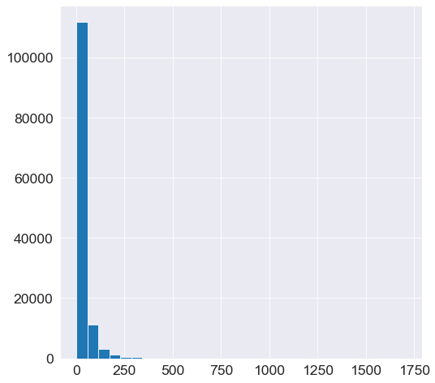

```python
df_cleaned['text_words'].hist(figsize=(8,8),bins=30);
```

### Check for the number of negative text words (blob)

> > Of course few words are easier for bots to create

```python
df_negative_blob['text_words'].value_counts().head(10)
```

```
6     1004
10    1000
7      994
9      994
11     994
8      992
14     987
12     942
15     910
13     873
Name: text_words, dtype: int64
```

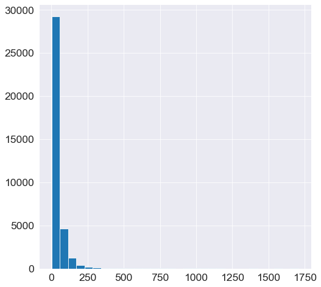

```python
df_negative_blob['text_words'].hist(figsize=(8,8),bins=30);
```

### Most commented user

```python
df_cleaned.author.value_counts()
```

```
-banned-                17396
AutoModerator            1679
5th_Law_of_Robotics       298
CelebBattleVoteBot        282
Support_Johnny_Depp       256
                        ...
Kensho1964                  1
noninflammatoryidiot        1
COBNYC                      1
thereallocal                1
agentorgy                   1
Name: author, Length: 53226, dtype: int64
```

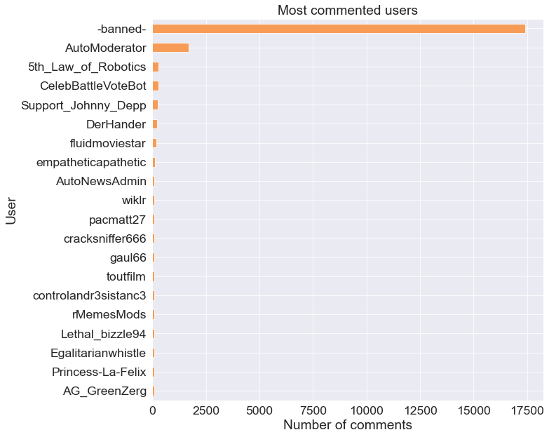

```python
df_cleaned.author.value_counts().head(20).plot(kind='barh', figsize=(10,10), color='#f69c56',
                                                       xlabel = 'User')

plt.gca().invert_yaxis()
plt.xlabel('Number of comments')
plt.title('Most commented users');
```

### Invesigating authors with the most negative comments / submissions (blob)

```python
df_negative_blob.author.value_counts()
```

```
-banned-                3509
AutoModerator            199
5th_Law_of_Robotics       86
rMemesMods                86
Support_Johnny_Depp       73
                        ...
Bejeweled_Bird             1
wastemytime1987            1
thepubclosesin5hours       1
BreathAbject671            1
the_joy_of_VI              1
Name: author, Length: 20887, dtype: int64
```

```python
df_negative_blob.author.value_counts().nlargest(n=25)
```

```
-banned-                3509
AutoModerator            199
5th_Law_of_Robotics       86
rMemesMods                86
Support_Johnny_Depp       73
lobofett12                46
KeepingDankMemesDank      44
fluidmoviestar            43
cracksniffer666           39
empatheticapathetic       34
king_of_red_alphas        31
Lethal_bizzle94           31
SharedRegime              30
pacmatt27                 29
wiklr                     29
bufedad                   28
AG_GreenZerg              28
Threwaway42               28
sassthehoopyfrood         27
particledamage            27
reptilesocks              27
controlandr3sistanc3      26
Fantastic_Bat             26
recovering_spaz           26
ADHDcUK                   23
Name: author, dtype: int64
```

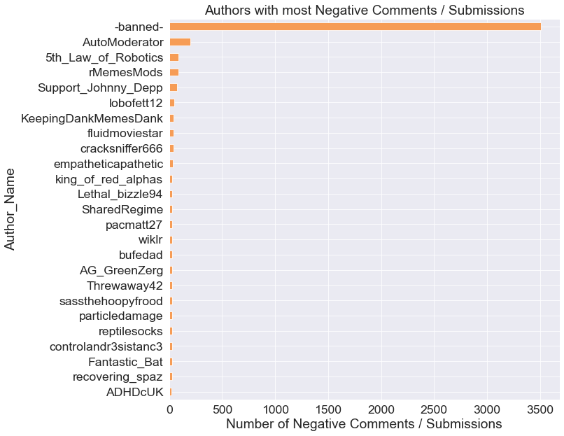

```python
df_negative_blob.author.value_counts().nlargest(n=25).plot(kind='barh', figsize=(10,10), color='#f69c56',
                                                       xlabel = 'Author_Name')

plt.gca().invert_yaxis()
plt.xlabel('Number of Negative Comments / Submissions')
plt.title('Authors with most Negative Comments / Submissions');
```

a lot of negative-comments authors have been banned from Reddit which is great!

### Invesigating authors with the most negative submissions (blob)

```python
df_negative_submission = df_negative_blob[df_negative_blob.submission_comment == 'submission']
print(df_negative_submission.shape)
df_negative_submission.head(2)
```

```
(1504, 14)
```

|  | name | permalink | text | parent_id | subreddit | author | created_at | entities.urls | sentiment_blob | sentiment_nltk | top_level | submission_comment | text_words | submission_text |
| --- | --- | --- | --- | --- | --- | --- | --- | --- | --- | --- | --- | --- | --- | --- |
| 0 | t3_ewweg2 | /r/MensRights/comments/ewweg2/amber_heard_admits_to_hitting_exhusband_johnny/ | Amber Heard admits to 'hitting' ex-husband Johnny Depp and pelting him with pots and pans on tape 'I can't promise I won't get physical again, I get so mad I lose it.' | NaN | r/MensRights | furchfur | 2020-01-31 22:45:00 | [] | Negative | Neutral | None | submission | 32 | amber_heard_admits_to_hitting_exhusband_johnny |
| 65 | t3_ew7b40 | /r/celebsnaked/comments/ew7b40/amber_heard_raw_sex_scene/ | Amber Heard Raw Sex Scene | NaN | r/celebsnaked | Bailloyon | 2020-01-30 15:45:39 | [] | Negative | Neutral | None | submission | 5 | amber_heard_raw_sex_scene |

```python
df_negative_submission.author.value_counts().nlargest(n=10)
```

```
-banned-               526
Support_Johnny_Depp     72
MetiNews                18
AutoNewsAdmin           15
TheAndredal             15
-en-                    13
newsfeedmedia           12
AutoNewspaperAdmin      12
hunt3r005                8
internewscast            8
Name: author, dtype: int64
```

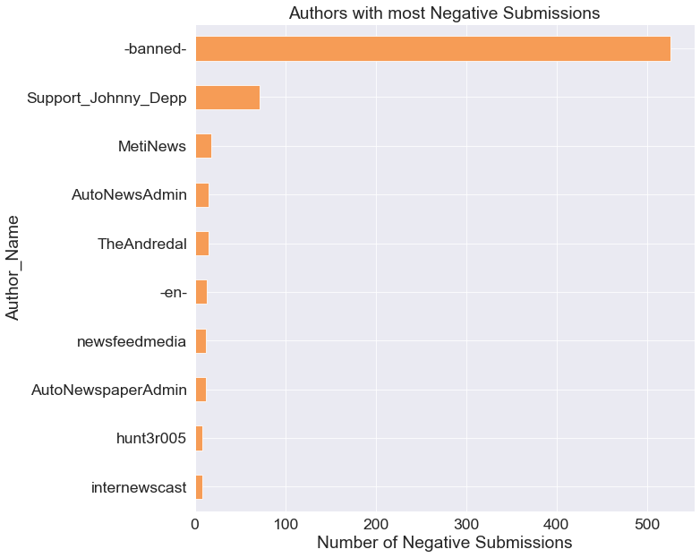

```python
df_negative_submission.author.value_counts().nlargest(n=10).plot(kind='barh', figsize=(10,10), color='#f69c56',
                                                       xlabel = 'Author_Name')

plt.gca().invert_yaxis()
plt.xlabel('Number of Negative Submissions')
plt.title('Authors with most Negative Submissions');
```

### Check wether the users contributing the most to negative comments are mod, gold or having a verified email

```python
df_negative_blob.author.value_counts().nlargest(n=25)
```

```
-banned-                3509
AutoModerator            199
5th_Law_of_Robotics       86
rMemesMods                86
Support_Johnny_Depp       73
lobofett12                46
KeepingDankMemesDank      44
fluidmoviestar            43
cracksniffer666           39
empatheticapathetic       34
king_of_red_alphas        31
Lethal_bizzle94           31
SharedRegime              30
pacmatt27                 29
wiklr                     29
bufedad                   28
AG_GreenZerg              28
Threwaway42               28
sassthehoopyfrood         27
particledamage            27
reptilesocks              27
controlandr3sistanc3      26
Fantastic_Bat             26
recovering_spaz           26
ADHDcUK                   23
Name: author, dtype: int64
```

```python
df_check['has_verified_email'].value_counts()
```

```
True     14
False     6
Name: has_verified_email, dtype: int64
```

```python
df_check['is_mod'].value_counts()
```

```
False    10
True     10
Name: is_mod, dtype: int64
```

```python
df_check['is_gold'].value_counts()
```

```
False    18
True      2
Name: is_gold, dtype: int64
```

### Most used Subreddits

```python
df_cleaned['subreddit'].nunique()
```

```
1164
```

[figure not shown]

```python
df_cleaned.subreddit.value_counts().head(20).plot(kind='barh', figsize=(10,10), color='#f69c56',
                                                       xlabel = 'subreddit')
plt.gca().invert_yaxis()
plt.xlabel('Number of comments')
plt.title('Most used subreddits');
```

### Invesigating subreddits with the most negative comments (blob)

```python
df_negative_blob.subreddit.value_counts().nlargest(n=25)
```

```
r/videos                  7542
r/entertainment           2690
r/MensRights              2360
r/awfuleverything         1960
r/pussypassdenied         1862
r/iamatotalpieceofshit    1493
r/memes                   1415
r/unpopularopinion         858
r/TrueOffMyChest           778
r/AskReddit                754
r/gifs                     599
r/worldnews                598
r/JerkOffToCelebs          574
r/DC_Cinematic             540
r/movies                   517
r/trashy                   431
r/shittymoviedetails       395
r/teenagers                346
r/PurplePillDebate         341
r/celebnsfw                328
r/harrypotter              291
r/boxoffice                258
r/kotakuinaction2          241
r/news                     239
r/OutOfTheLoop             213
Name: subreddit, dtype: int64
```

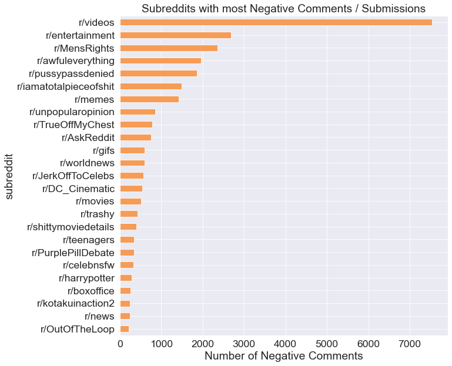

```python
df_negative_blob.subreddit.value_counts().nlargest(n=25).plot(kind='barh', figsize=(10,10), color='#f69c56',
                                                       xlabel = 'subreddit')

plt.gca().invert_yaxis()
plt.xlabel('Number of Negative Comments')
plt.title('Subreddits with most Negative Comments / Submissions');
```

### Submission URLS

```python
df_cleaned['entities.urls'].nunique()
```

```
1086
```

```python
df_cleaned['urls'].astype('str').value_counts()
```

```
[]                                                                                                                                                             123195
['https://www.reddit.com']                                                                                                                                        470
['https://youtu.be']                                                                                                                                              342
['https://www.youtube.com']                                                                                                                                       197
['http://chng.it']                                                                                                                                                190
                                                                                                                                                                ...
['https://m.youtube.com', 'https://i.imgur.com', 'https://i.imgur.com', 'https://m.youtube.com', 'https://i.imgur.com', 'https://m.youtube.com']                    1
['https://www.timesofisrael.com']                                                                                                                                   1
['https://theblast.com', 'https://www.insider.com', 'https://www.aol.com', 'https://www.huffpost.com', 'https://www.foxnews.com', 'https://www.who.com.au']         1
['https://youtu.be', 'https://www.reddit.com']                                                                                                                      1
['https://www.foxnews.com', 'https://www.foxnews.com']                                                                                                              1
Name: urls, Length: 1086, dtype: int64
```

```python
# the value counts of urls count
df_cleaned['urls_count'].value_counts()
```

```
0     123195
1       3288
2       1133
3        316
5        172
4        155
6         86
8         13
7         11
9          8
10         6
20         5
16         3
12         3
18         2
19         2
11         2
22         2
17         1
23         1
24         1
26         1
27         1
37         1
Name: urls_count, dtype: int64
```

### Invesigating the sumbissions with most comments

```python
df_cleaned.parent_id.value_counts().nlargest(n=25)
```

```
t3_eyp2d3    1695
t3_f0q0ao    1203
t3_kdznjp     940
t3_hkp7lo     831
t3_fwf5kv     479
t3_jpysmx     431
t3_exjob5     324
t3_ipxsbo     300
t3_jpu8sh     261
t3_jprejw     243
t3_gczkex     241
t3_f0spbd     236
t3_exlayd     228
t3_jplud5     223
t3_jpcjq3     219
t3_f05a17     202
t3_f0x1mb     198
t3_gco2dn     196
t3_htg6z5     193
t3_ewymip     190
t3_k3s8rt     185
t3_jvbur4     185
t3_jps57u     185
t3_k09s59     179
t3_f07wzt     176
Name: parent_id, dtype: int64
```

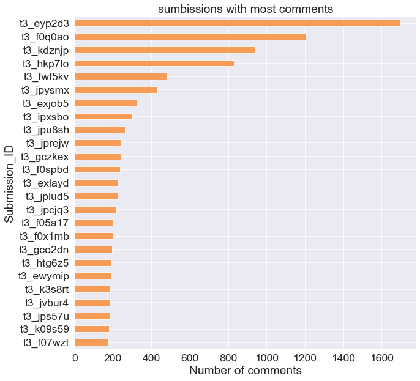

```python
df_cleaned.parent_id.value_counts().nlargest(n=25).plot(kind='barh', figsize=(10,10), color='#f69c56',
                                                       xlabel = 'Submission_ID')

plt.gca().invert_yaxis()
plt.xlabel('Number of comments')
plt.title('sumbissions with most comments');
```

### Invesigating submissions with the most negative comments (blob)

```python
df_negative_blob.parent_id.value_counts().nlargest(n=25)
```

```
t3_eyp2d3    630
t3_f0q0ao    458
t3_hkp7lo    315
t3_kdznjp    271
t3_jpysmx    133
t3_exjob5    110
t3_fwf5kv    109
t3_jprejw    107
t3_f0x1mb    103
t3_jplud5     90
t3_ewymip     84
t3_ipxsbo     82
t3_gczkex     80
t3_exlayd     78
t3_gco2dn     75
t3_jps57u     74
t3_jvbur4     72
t3_f05a17     69
t3_htg6z5     68
t3_eze53r     67
t3_f0spbd     65
t3_f07wzt     63
t3_jpcjq3     61
t3_ez4hyb     60
t3_fxqlit     60
Name: parent_id, dtype: int64
```

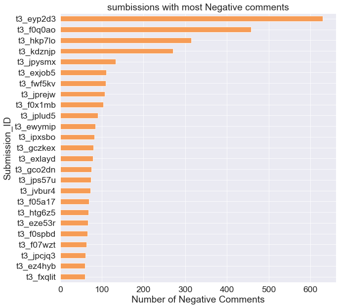

```python
df_negative_blob.parent_id.value_counts().nlargest(n=25).plot(kind='barh', figsize=(10,10), color='#f69c56',
                                                       xlabel = 'Submission_ID')

plt.gca().invert_yaxis()
plt.xlabel('Number of Negative Comments')
plt.title('sumbissions with most Negative comments');
```

- Daily Creation Data
- User Charcterstics
- Reddit Comments/Submissions Data
- **Merged Users Data with Comments/Submissions Data**

### Merging Users Data with Comments & Submissions Data

### Difference in time between creating the account and posting

```python
# note that value_counts() neglect Zeros
reddit_df["days_after_account_creation"].value_counts()
```

[output not shown]

```python
reddit_df["days_after_account_creation"].hist(figsize = (10, 10) , bins = 30);
```

[output not shown]

### Posting Duration After Account Creation

```python
reddit_df[reddit_df['days_after_account_creation'] == 0].shape[0]
```

[output not shown]

```python
reddit_df[reddit_df['days_after_account_creation'] <= 7].shape[0]
```

[output not shown]

```python
reddit_df[reddit_df['days_after_account_creation'] <= 30].shape[0]
```

[output not shown]

```python
reddit_df[reddit_df['days_after_account_creation'] <= 30]['created_at'].dt.year.value_counts()
```

[output not shown]

### Estimation of Number of User Accounts Created / having negative contributions

```python
# the negative contributions of user accounts created in each year
negative_contributions = reddit_negative.groupby(reddit_negative['created_at'].dt.year).size().reset_index(name='year_count')
negative_contributions
```

[output not shown]

```python
negative_contributions.plot(x="created_at", y="year_count", kind="bar", figsize=(14,7), color='#f69c56')
plt.xlabel('Year')
plt.ylabel('Number of User Accounts Created')
plt.title('Number of User Accounts Created over Years / having negative contributions');
```

[output not shown]

### Which dates has the highest contrbitions for users?

```python
top_trendy_dates.head(15).reset_index().plot(x='created_at', y="contribution_count", kind="bar", figsize=(14,7), color='#f69c56')
plt.xlabel('Date')
plt.ylabel('Number of contrbutions')
plt.title('Number of contrbutions Comment/Submission in trendy dates');
```

[output not shown]

```python
reddit_df.hist(figsize=(14,7), color='#f69c56', xrot = 90);
# plt.xticks(rotation=90);
```

[output not shown]

```python
# Contributions Submissions/Comments Time Series For 2018
date = df_cleaned['created_at'].dt.date

fig, ax = plt.subplots()
fig.set_size_inches(11.7, 8.27)
sns.countplot(x = date, data = df_cleaned)
ax.xaxis.set_major_locator(mdates.MonthLocator())
ax.xaxis.set_major_formatter(mdates.DateFormatter('%b'))
#plt.xticks([1,2,3,4,5,6,7,8,9,10,11,12])
plt.xlabel('Dates')
plt.ylim(0,250)
plt.ylabel('Count')
plt.title('Contributions Submissions/Comments Time Series')
plt.show()
```

[output not shown]

In Which days users created more?

```python
week_day = df_cleaned['created_at'].dt.strftime('%a')
week_day.value_counts()
```

[output not shown]

```python
week_day.value_counts().plot(kind='bar', color='#f69c56');
plt.gca().invert_xaxis()
```

[output not shown]

In Which months users created more?

```python
month_day = df_cleaned['created_at'].dt.strftime('%b')
month_day.value_counts()
```

[output not shown]

```python
month_day.value_counts().plot(kind='bar', color='#f69c56');
plt.gca().invert_xaxis()
```

[output not shown]

### Which dates has the highest negative contrbitions for users?

```python
top_trendy_negative.head(15).reset_index().plot(x='created_at', y="contribution_count", kind="bar", figsize=(14,7), color='#f69c56')
plt.xlabel('Date')
plt.ylabel('Number of negative contrbutions')
plt.title('Number of negative contrbutions over Years');
```

[output not shown]

```python
# Negative Contributions Submissions/Comments Time Series For 2018
date = df_negative_blob['created_at'].dt.date

fig, ax = plt.subplots()
fig.set_size_inches(11.7, 8.27)
sns.countplot(x = date, data = df_negative_blob)
ax.xaxis.set_major_locator(mdates.MonthLocator())
ax.xaxis.set_major_formatter(mdates.DateFormatter('%b'))
#plt.xticks([1,2,3,4,5,6,7,8,9,10,11,12])
plt.xlabel('Dates')
plt.ylim(0,100)
plt.ylabel('Count')
plt.title('Negative Contributions Submissions/Comments Time Series')
plt.show()
```

[output not shown]

In Which days accounts created more negative comments

```python
week_day_negative = df_negative_blob['created_at'].dt.strftime('%a')
week_day_negative.value_counts()
```

[output not shown]

```python
week_day_negative.value_counts().plot(kind='bar', color='#f69c56');
plt.gca().invert_xaxis()
```

[output not shown]

In Which months accounts created more negative comments?

```python
month_day_negative = df_negative_blob['created_at'].dt.strftime('%b')
month_day_negative.value_counts()
```

[output not shown]

```python
month_day_negative.value_counts().plot(kind='bar', color='#f69c56');
plt.gca().invert_xaxis()
```

[output not shown]

- Introduction
- Data Wrangling
- Data Cleaning
- Exploratory Data Analysis
- **Conclusions**